# Coursework 2

##### Urte Adomaityte, CID 01356309

##### This is my own work unless stated otherwise.

## Task 1

In this task, I will perform a classification task using supervised learning, moree specifically, neural networks on the CIFAR-10 dataset of images. It contains 50,000 training and 10,000 testing images, each belonging to 10 classes.

```python
import numpy as np
import tensorflow as tf
import matplotlib.pyplot as plt
```

##### Getting the data ready

```python
def load_data():
    (x_train, y_train), (x_val, y_val) = tf.keras.datasets.cifar10.load_data()
    x_train = x_train.astype('float32') / 255
    x_val = x_val.astype('float32') / 255
    # convert labels to categorical samples
    y_train = tf.keras.utils.to_categorical(y_train, num_classes=10)
    y_val = tf.keras.utils.to_categorical(y_val, num_classes=10)
    return ((x_train, y_train), (x_val, y_val))

(x_train, y_train), (x_val, y_val) = load_data()  # load the CIFAR-10 dataset
```

```python
print(x_train.shape)
print(y_train.shape)
print(x_val.shape)
print(y_val.shape)
```

```
(50000, 32, 32, 3)
(50000, 10)
(10000, 32, 32, 3)
(10000, 10)
```

From the shapes of the data, we can see that in

- x_train and x_val: we have 50,000 and 10,000 (train and val, resp.) images of size 32x32 pixels, the last dimension 3 corresponds to the RBG (red-blue-green) colour scheme, so these images are coloured,
- y_train, y_val: we have 50,000 and 10,000 (train and val, resp.) probability vectors that correspond to each image being assigned to one of the 10 classes with probability 1, with other entries baing zeros. Recall that this is supervised learning, so this is our 'ground truth'.

Now print a few examples of out train dataset using the code from the tutorial:

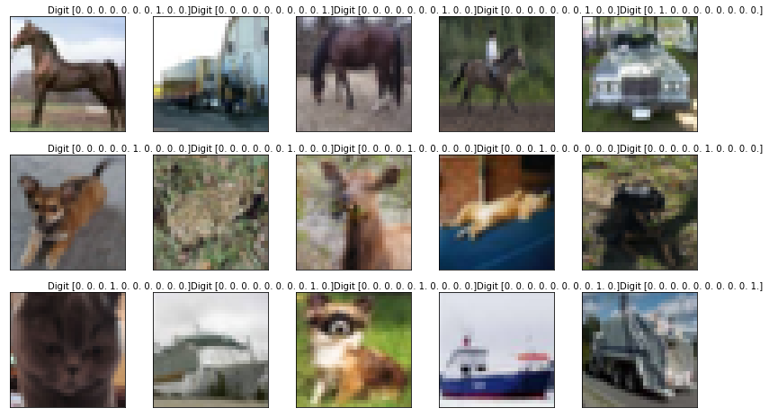

```python
n_rows, n_cols = 3, 5
random_inx = np.random.choice(x_train.shape[0], n_rows * n_cols, replace=False)
fig, axes = plt.subplots(n_rows, n_cols, figsize=(14, 8))
fig.subplots_adjust(hspace=0.2, wspace=0.1)

for n, i in enumerate(random_inx):
    row = n // n_cols
    col = n % n_cols
    axes[row, col].imshow(x_train[i])
    axes[row, col].get_xaxis().set_visible(False)
    axes[row, col].get_yaxis().set_visible(False)
    axes[row, col].text(10., -1.5, f'Digit {y_train[i]}')
plt.show()
```

Notice that these are indeed colour images, and we see that the second class in the precidtion vector is for cars, the eigth is for horses etc.

We start by flattening our multi-dimensional data to feed it into the MLP, as shown in the tutorial.

#### 1.1. Multi-Layer Perceptron

In this section, I will show my implementation of the multi-layer perceptron with:

- 5 hidden layers,
- 400 neurons in each layer,
- 10 output labels corresponding to each class of the image,
- activation function between layers: standardised tanh
- activation function on output layer: softmax
- optimisation method: SGD
- loss function: cross-entropy, since we want a measure of how close we are to the true prediction, we are dealing with a probability distribution of belonging to each of the 10 classes

Training: on 128 batches, learning rate $\mu=0.01$, 40 epochs.

Output: loss function and accuracy of the model for both training and validation sets plotted against epochs.

##### Defining the functions

We define the loss function we will use in the stochastic gradient descent: cross entropy. The formula for that is $$ L(\theta) = -\frac{1}{|\mathcal{D}_{train}|} \sum_{x_i\in\mathcal{D}_{train}}\sum_{j=1}^{10} \tilde{y}_{ij} \ln f_\theta(x_i)_j, $$ where $\mathcal{D}_{train}$ is the randomly sampled minibatch of 128 training data, which is the reason why SGD is cheaper and faster than the full gradient descent that uses the full dataset.

Recall that the parameters are $\theta$, $f_\theta$ is the neural network function that outputs a length 10 probability vector $f_\theta(x_i)\in\mathbb{R}^{10}$, and $\tilde{y}_{ij}$ is 1 if the correct label for example $i$ is $j$, and 0 otherwise.

```python
# define the optimised cross entropy loss function, only taking into account the non-zero validation value
# this saves us 9 log computations that are useless as we multiply them by 0
def cross_entropy_loss_opt(y_pred, y_val):
    '''
    y_val is a length-10 vector the ground truth classification corresponding to that minibatch
    y_pred is the length-10 predicted value by f_theta with these parameters
    '''
    n = y_pred.shape[0]
    loss = 0
    for i in range(n):
        k = np.argmax(y_val[i])
        loss -= y_val[i,k]*np.log(y_pred[i,k] + 1e-6)  # need to add the small valuee to avoid log(0)
    return loss/n  # divide by number of predictions
```

To perform the stochastic gradient descent, we need to define the gradient $$ \nabla_\theta L (\theta_t; \mathcal{D}_{train}), $$

where we used the cross entropy loss function for $l(y_i,f_\theta(x_i))$.

We initialise the weights by a random initial guess $\theta_0$ and update the parameter (weight and bias) values using the update rule

$$ \theta_{t+1} = \theta_t - \eta \nabla_\theta L (\theta_t; \mathcal{D}_{train}),$$

The activation function for the output layer $\sigma_{out}$ is the softmax function, which turns the last pre-activation vector $\textbf{a} \in \mathbb{R}^D$ into a probability vector of the same dimension $\hat{\textbf{y}} \in \mathbb{R}^D$ as such: $$ \hat{y}_j = \sigma_{softmax}(\textbf{a}^{(L+1)})_j = \frac{e^{a_j}}{\sum^D_{i=1} e^{a_i}}, $$

```python
# define the activation function we will use for the output layer
def softmax(x):
    e = np.exp(x)
    return e / e.sum(axis=1)[:,None]
```

We will use the standardised $tanh(x)$ activation function in the hidden layers, below we define its derivative which we will use in the gradient descent.

```python
def sigma_tanh_derivative(a):
    h = 1 - np.square(np.tanh(a))
    return h
```

We now proceed to define the MLP with 5 hidden layers: $$ \begin{align} \boldsymbol{h}^{(0)} &= \boldsymbol{x},\\ \boldsymbol{h}^{(k)} &= \sigma_{tanh}(\textbf{a}^{(k)}) = \sigma_{tanh} \left((\boldsymbol{h}^{(k-1)})^T \boldsymbol{W}^{(k-1)} + \boldsymbol{b}^{(k-1)} \right),\qquad k=1,2,3,4,5\\ \hat{\boldsymbol{y}} &= \sigma_{softmax}\left((\boldsymbol{h}^{(5)})^T \boldsymbol{W}^{(5)} + \boldsymbol{b}^{(5)} \right) \end{align} $$

The MLP will need these parameters:

Hidden layer -> hidden layer:

- Kernel $\boldsymbol{W}^{(k)} \in\mathbb{R}^{400\times 400}$, $k=1, 2, 3, 4$
- Bias $\boldsymbol{b}^{(k)} \in\mathbb{R}^{400}$, $k=1, 2, 3, 4$

Hidden layer -> output layer:

- Kernel $\boldsymbol{W}^{(5)} \in\mathbb{R}^{400\times 10}$
- Bias $\boldsymbol{b}^{(5)} \in\mathbb{R}^{10}$

Use Glorot initialisation for the weights and zeros for the bias:

```python
def init_params():
    var0 = 2. / (400 + 3072)
    W0 = np.random.randn(3072, 400) * np.sqrt(var0)
    b0 = np.zeros(400)

    var1 = 2. / (400 + 400)
    W1 = np.random.randn(400, 400) * np.sqrt(var1)
    b1 = np.zeros(400)

    var2 = 2. / (400 + 400)
    W2 = np.random.randn(400, 400) * np.sqrt(var2)
    b2 = np.zeros(400)

    var3 = 2. / (400 + 400)
    W3 = np.random.randn(400, 400) * np.sqrt(var3)
    b3 = np.zeros(400)

    var4 = 2. / (400 + 400)
    W4 = np.random.randn(400, 400) * np.sqrt(var4)
    b4 = np.zeros(400)

    var5 = 2. / (10 + 400)
    W5 = np.random.randn(400, 10) * np.sqrt(var5)
    b5 = np.zeros(10)

    W = [W0,W1,W2,W3,W4,W5]  # weight list
    b = [b0, b1, b2, b3, b4, b5]  # bias list

    return W, b
```

We now define the function to compute the pre-activations $\textbf{a}^{(k)} = (\boldsymbol{h}^{(k-1)})^T \boldsymbol{W}^{(k-1)} + \boldsymbol{b}^{(k-1)} $

```python
def dense(h, W, b):
    '''
    h: K x h_in=3072 (or 400) array of inputs
    W: h_in=3072 (or 400) x h_out=400 (in output layer=10) array for kernel matrix parameters
    b: h_out=400 (in output layer=10) length 1-D array for bias parameters
    returns: K x h_out=400 (in output layer=10) output array
    '''
    a = h @ W + b
    return a
```

Define the forward-propagation that gives us the predictions without saving the activations:

```python
def mlp_get_y(x, W, b):
    '''
    x: array of inputs
    W: list of weights
    b: list of biases
    returns: y_pred of the MLP with these parameters
    '''
    a1 = dense(x, W[0], b[0])
    h1 = np.tanh(a1)  # hidden layer 1
    a2 = dense(h1, W[1], b[1])
    h2 = np.tanh(a2)  # hidden layer
    a3 = dense(h2, W[2], b[2])
    h3 = np.tanh(a3)  # hidden layer 3
    a4 = dense(h3, W[3], b[3])
    h4 = np.tanh(a4)  # hidden layer 4
    a5 = dense(h4, W[4], b[4])
    h5 = np.tanh(a5)  # hidden layer 5
    a6 = dense(h5, W[5], b[5])
    y = softmax(a6)  # output layer
    return y
```

We now define the function that does the forward propagation through the layers and saves the pre- and post-activations:

```python
def forward_prop(X, W, b):
    '''
    X: array of inputs
    W: list containing weight matrices for each layer
    b: list containing bias vectors for each layer
    returns: output array, list containing the pre-activations
    '''
    A = []
    H = [X]  # the initial post-activation value is the input data

    a1 = dense(X, W[0], b[0]) # hidden layer 1
    A.append(a1)
    h1 = np.tanh(a1)
    H.append(h1)

    a2 = dense(h1, W[1], b[1]) # hidden layer 2
    A.append(a2)
    h2 = np.tanh(a2)
    H.append(h2)

    a3 = dense(h2, W[2], b[2]) # hidden layer 3
    A.append(a3)
    h3 = np.tanh(a3)
    H.append(h3)

    a4 = dense(h3, W[3], b[3])  # hidden layer 4
    A.append(a4)
    h4 = np.tanh(a4)
    H.append(h4)

    a5 = dense(h4, W[4], b[4])   # hidden layer 5
    A.append(a5)
    h5 = np.tanh(a5)
    H.append(h5)

    a6 = dense(h5, W[5], b[5])  # output layer
    A.append(a6)
    y = softmax(a6)
    H.append(y)

    return A, H
```

Note that we need to save the pre-activations A and the post-activations H in memory in order to use them in the back-propagation.

We also define function that samples the batches randomly from the train data.

```python
# select random 128 samples of data
def gen_flat_batch(x_train,y_train,batch_size=128):
    '''
    output: batches of input data of specified size, x_batch is flattened
    '''
    idx = np.random.randint(x_train.shape[0], size=batch_size)
    x_train_batch = x_train[idx,:]
    y_train_batch = y_train[idx,:]
    x_train_batch = x_train_batch.reshape((x_train_batch.shape[0], -1))
    return x_train_batch, y_train_batch

x_train_batch, y_train_batch = gen_flat_batch(x_train,y_train,batch_size=128)
print(y_train_batch)  # categorical outcomes
```

```
[[0. 0. 0. ... 0. 0. 0.]
 [0. 1. 0. ... 0. 0. 0.]
 [0. 0. 0. ... 0. 0. 0.]
 ...
 [0. 0. 0. ... 0. 1. 0.]
 [0. 1. 0. ... 0. 0. 0.]
 [0. 0. 0. ... 0. 0. 0.]]
```

Now call the forward-feed with the randomly generated data and check the dimensions.

```python
# initialise the parameters
W, b = init_params()
```

```python
A, H = forward_prop(x_train_batch, W, b)
```

```python
print(y_pred_batch.shape)  # check we have 128 predictions of length 10
print(len(A))  # check A has 6 elements for 6 layers
print(len(H))  # is 7 because it includes the input X
print(W[0].shape)  # check the input dim is 3072
print(A[5].shape)  # check the output activation dim is 10
print(b[0].shape)  # check the bias for the first layer corresponds to the nb of neirons in the first layer 400
```

```
(128, 10)
6
7
(3072, 400)
(128, 10)
(400,)
```

We can also check if the loss value makes sense, i.e., it is a relatively small float value:

```python
cross_entropy_loss_opt(y_pred_batch,y_train_batch)
```

```
2.4517192573197137
```

We now have initialised random guesses for the parameters, defined the functions required for the forward pass and saved the pre- and post-activations that we will use next. Now, we need to define the backward pass that will drive the optimisation of the parameters.

The main task is now to define the gradients of the loss function $L$ with respect to the parameters $\textbf{W}$ and $\textbf{b}$ at each layer. Recall from the lectures that for the shorthand notation $$\delta^{(k)}_{p} = \frac{\partial L_i}{\partial a^{(k)}_p}, $$

we have the definition for the gradients w.r.t. the weights and biases:

$$ \frac{\partial L_i}{\partial W^{(k)}_{pq}} = \delta^{(k+1)}_{p} h^{(k)}_q, \hspace{5mm} \frac{\partial L_i}{\partial b^{(k)}_{p}} = \delta^{(k+1)}_{p} $$

The gradient that we need to compute at the output layer involves the parameters in the pre-activation $\textbf{a}^{(k)} = (\boldsymbol{h}^{(k-1)})^T \boldsymbol{W}^{(k-1)} + \boldsymbol{b}^{(k-1)} $ under the softmax activation function, and the derivative of the loss function for each $x,y$ in the batch, $l(\theta)$, which we express in terms of the pre-activations $\textbf{a}$ in the output layer is

$$l(\textbf{a}) = - \sum_i y_i log(\hat{y}_i),$$

where $\hat{y}_i = \sigma_{softmax}(a_i) = \frac{e^{a_i}}{\sum_j e^{a_j}}. $

Recall that $y_i$ is the 'ground' truth vector with, say 1 at index $k$ and 0 in all others $j\neq k$, so we can simplify the notation of the loss function: $$l(\textbf{a}) = - log(\hat(y_k)) = - log( \frac{e^{a_i}}{\sum_j e^{a_j}} ) = -a_k + log(\sum_j e^{a_j})$$

Take the derivative of this simplified form: (source: Ian H. Witten et al., "Data Mining: Practical Machine Learning Tools and Techniques, Fourth Edition" 2017, Chapter 10: Deep Learning, p.427, DOI: https://doi.org/10.1016/C2015-0-02071-8)

$$ \frac{\partial l}{\partial a_j} = - \frac{\partial a_k}{\partial \textbf{a}} + \frac{\partial}{\partial a_j} log(\sum e^{a_j}) = -y_{true} + \frac{e^{a_i}}{\sum_j e^{a_j}}= - y_{true} + \hat{y} . $$

since we have that $\frac{\partial a_j}{\partial a_j} = 1 $ and for $i\neq j$, $\frac{\partial a_i}{\partial a_j} = 0$.

Therefore, we compute the delta in the output layer L(=6) to be

$$ \delta^{(L)}_{p} = \frac{\partial L}{\partial a_i} = \hat{y} - y_{true}. $$

We then compute the deltas for the previous layers iteratively backwards:

$$ \delta^{(k)} = \sigma ' (a^{(k)}) (W^{(k)})^T \delta^{(k+1)}, $$

where $\sigma '(a^{(k)})$ is the diagonal matrix containing the values of the pre-activations evaluated at the derivatives of the activation function used at that layer.

Define the mean accuracy

```python
def accuracy(y_pred,y_val):
    n = y_pred.shape[0]
    correct = 0
    for i in range(n):
        if np.argmax(y_pred[i])==np.argmax(y_val[i]):  # checks if the index of preciction 1 is the same
            correct += 1
    return correct/n
```

Define the function that converts a probability vector into a one-hot vector, i.e., that sets the maximum netry to 1 and all others to 0:

```python
def prob_to_one(y):
    n,m = y.shape
    y_pred = np.zeros((n,m))
    for i in range(n):
        index = np.argmax(y[i,:]) # get the index of maximum value in vector
        y_pred[i,index] = 1  # set that value of y_pred to 1
    return y_pred
```

Define the function that computes the $\delta$'s according to the backward propagation formula $ \delta^{(k)} = \sigma ' (a^{(k)}) (W^{(k)})^T \delta^{(k+1)}$:

```python
def backward_propagation(W, b, A, delta_6, n_layers=5):
    '''
    W: weights
    b: biases
    A: list containing the pre-activations
    delta_6: the last error
    n_layers: number of layer indices
    output: the delta errors
    '''
    ind = n_layers
    deltas = [delta_6]
    while ind>=1:
        d_a = sigma_tanh_derivative(A[ind-1])
        # using an indexing trick to get around dimension problems with 1-D and 2-D tuples
        deltas.insert(0, d_a*(W[ind]@(deltas[0][...,np.newaxis])).squeeze() )
        ind-=1
    return deltas
```

We now have all the ingredients to update the weights and biases. Note this function computes the update for the whole batch at the same time.

```python
def get_gradients(deltas, H, n_layers=5, batch_size=128):
    dW = []
    db = []
    # iterate through the layers, +1 since we have 7 elements in H (0 is initial data)
    for i in range(n_layers+1):
        dW.append(np.dot(H[i].T,deltas[i])/batch_size)  # normalise the weight update by the batch size
        db.append(np.mean(deltas[i], axis=0))  # the bias update is simply the error of the layeer k+1
    return dW, db
```

Define the parameter optimisation function, given a batch, weights, biases to update and a learning rate

```python
def optimise_params(x_batch, y_batch, W, b, learning_rate, batch_size=128, n_layers=5):
    # FORWARD PASS
    A, H = forward_prop(x_batch, W, b)  # get A, H

    # BACKWARD PASS
    delta_6 = H[-1]-y_batch  # get output layer delta_6 - we have derived this formula above
    deltas = backward_propagation(W, b, A, delta_6, n_layers=5)  # get deltas

    # we now have the deltas, the pre- and post-activations
    # compute the updated weights and gradients over the whole batch

    # SGD
    dW, db = get_gradients(deltas, H, n_layers=5, batch_size=128)
    for i in range(6):
        W[i] -= learning_rate * dW[i]
        b[i] -= learning_rate * db[i]

    return W, b
```

Finally, define the training function over a number of epochs, given training and validation sets.

```python
def train_mlp(x_train, y_train, x_valid, y_val, epochs, learning_rate, batch_size=128):
    losses_train_total = []
    losses_val_total = []
    accs_train_total = []
    accs_val_total = []
    x_val = x_valid.reshape((x_valid.shape[0], -1)) # flatten the validation set
    W, b = init_params()  # initialise patameters
    for i in range(epochs):
        losses_train = []
        losses_val = []
        accs_train = []
        accs_val = []
        for j in range(390): # set number of batches to loop over in one epoch: 390 to go through the whole dataset
            x_batch, y_batch = gen_flat_batch(x_train,y_train,batch_size) # sample one batch

            W_new, b_new = optimise_params(x_batch, y_batch, W, b, learning_rate, batch_size=128, n_layers=5)

            # given updated weights, get y_pred
            y_pred_train = mlp_get_y(x_batch, W_new, b_new)
            y_pred_hot = prob_to_one(y_pred_train)

            W = W_new
            b = b_new

            # training loss
            loss_train = cross_entropy_loss_opt(y_pred_hot, y_batch)
            losses_train.append(loss_train)
            # training accuracy
            acc_train = accuracy(y_pred_hot,y_batch)
            accs_train.append(acc_train)

        # aggregate the training metrics
        epoch_loss_train = sum(losses_train)/len(losses_train)
        losses_train_total.append(epoch_loss_train)

        epoch_acc_train = sum(accs_train)/len(accs_train)
        accs_train_total.append(epoch_acc_train)


        # evaluate the validation metrics
        y_pred_val = mlp_get_y(x_val, W, b)  # get prediction with updated weights after epoch
        y_pred_hot_val = prob_to_one(y_pred_val)  # turn it into binary vector
        # val loss
        loss_val = cross_entropy_loss_opt(y_pred_hot_val, y_val)
        losses_val_total.append(loss_val)
        # val accuracy
        acc_val = accuracy(y_pred_hot_val,y_val)
        accs_val_total.append(acc_val)

        print('epoch',i+1,'train loss:', epoch_loss_train, 'train acc:', epoch_acc_train,'val loss:', loss_val, 'val acc:', acc_val)

    return W, b, losses_train_total, accs_train_total, losses_val_total, accs_val_total
```

### 1.1.1

Train the model with 128 batches, 0.01 learning rate for 40 epochs.

```python
(x_train, y_train), (x_val, y_val) = load_data()  # load the CIFAR-10 dataset

epochs = 40
learning_rate = 0.01
W, b, losses_train, accs_train, losses_val, accs_val = train_mlp(x_train, y_train, x_val, y_val,
                                                                 epochs, learning_rate, batch_size=128)
```

```
epoch 1 train loss: 8.946594395318893 train acc: 0.3524238782051282 val loss: 8.78666435086594 val acc: 0.364
epoch 2 train loss: 8.19465639646097 train acc: 0.40685096153846156 val loss: 8.763177981217419 val acc: 0.3657
epoch 3 train loss: 7.952774242982196 train acc: 0.42435897435897435 val loss: 8.712060588452946 val acc: 0.3694
epoch 4 train loss: 7.677128219109368 train acc: 0.4443108974358974 val loss: 8.547656000913127 val acc: 0.3813
epoch 5 train loss: 7.46845642995262 train acc: 0.4594150641025641 val loss: 7.9259579808046094 val acc: 0.4263
epoch 6 train loss: 7.390135320759839 train acc: 0.4650841346153846 val loss: 7.819578541808275 val acc: 0.434
epoch 7 train loss: 7.22602077040181 train acc: 0.476963141025641 val loss: 7.874840588040119 val acc: 0.43
epoch 8 train loss: 7.14742290817301 train acc: 0.48265224358974357 val loss: 7.829249399898847 val acc: 0.4333
epoch 9 train loss: 7.0339541634060865 train acc: 0.4908653846153846 val loss: 7.5432683106489025 val acc: 0.454
epoch 10 train loss: 6.947607216168815 train acc: 0.4971153846153846 val loss: 7.717343756279312 val acc: 0.4414
epoch 11 train loss: 6.805632908692137 train acc: 0.5073918269230769 val loss: 7.8223416441198514 val acc: 0.4338
epoch 12 train loss: 6.689673386601056 train acc: 0.5157852564102564 val loss: 7.5087295317540015 val acc: 0.4565
epoch 13 train loss: 6.655909516206993 train acc: 0.5182291666666666 val loss: 7.20478827747863 val acc: 0.4785
epoch 14 train loss: 6.569009062897686 train acc: 0.5245192307692308 val loss: 7.425836462406147 val acc: 0.4625
epoch 15 train loss: 6.522791305882865 train acc: 0.5278645833333333 val loss: 7.289062897982253 val acc: 0.4724
epoch 16 train loss: 6.4054480186116995 train acc: 0.5363581730769231 val loss: 7.050054548029357 val acc: 0.4897
epoch 17 train loss: 6.334045735319336 train acc: 0.5415264423076923 val loss: 7.149526231246749 val acc: 0.4825
epoch 18 train loss: 6.230816852885034 train acc: 0.5489983974358974 val loss: 7.381626825420698 val acc: 0.4657
epoch 19 train loss: 6.172145209249446 train acc: 0.5532451923076923 val loss: 7.069396264210531 val acc: 0.4883
epoch 20 train loss: 6.084968002904134 train acc: 0.5595552884615385 val loss: 7.3788637231090615 val acc: 0.4659
epoch 21 train loss: 6.065041784310913 train acc: 0.5609975961538461 val loss: 7.130184515065585 val acc: 0.4839
epoch 22 train loss: 6.000558326918979 train acc: 0.5656650641025641 val loss: 7.251761016775728 val acc: 0.4751
epoch 23 train loss: 5.9399494120312735 train acc: 0.5700520833333333 val loss: 6.80551999345327 val acc: 0.5074
epoch 24 train loss: 5.838657800849086 train acc: 0.5773838141025641 val loss: 6.903610125514887 val acc: 0.5003
epoch 25 train loss: 5.771960319169016 train acc: 0.5822115384615385 val loss: 7.027949729536647 val acc: 0.4913
epoch 26 train loss: 5.713288675533432 train acc: 0.5864583333333333 val loss: 6.7143376171706635 val acc: 0.514
epoch 27 train loss: 5.631923282944461 train acc: 0.5923477564102564 val loss: 6.936767353254026 val acc: 0.4979
epoch 28 train loss: 5.598712918622436 train acc: 0.5947516025641025 val loss: 6.899465472047496 val acc: 0.5006
epoch 29 train loss: 5.512919477457195 train acc: 0.6009615384615384 val loss: 6.841440323504017 val acc: 0.5048
epoch 30 train loss: 5.395852943222045 train acc: 0.6094350961538462 val loss: 6.746113293753999 val acc: 0.5117
epoch 31 train loss: 5.343546619414848 train acc: 0.6132211538461538 val loss: 6.829006363101843 val acc: 0.5057
epoch 32 train loss: 5.323620400821631 train acc: 0.6146634615384615 val loss: 6.68946969636632 val acc: 0.5158
epoch 33 train loss: 5.303970935264431 train acc: 0.6160857371794872 val loss: 6.581708706214152 val acc: 0.5236
epoch 34 train loss: 5.1705759719042845 train acc: 0.6257411858974359 val loss: 6.816572402699665 val acc: 0.5066
epoch 35 train loss: 5.126848992213613 train acc: 0.62890625 val loss: 6.538880620384451 val acc: 0.5267
epoch 36 train loss: 5.1157788707729415 train acc: 0.629707532051282 val loss: 6.592761115460524 val acc: 0.5228
epoch 37 train loss: 5.014487259590753 train acc: 0.6370392628205128 val loss: 6.708811412547475 val acc: 0.5144
epoch 38 train loss: 4.897143972319589 train acc: 0.6455328525641025 val loss: 6.743350191442402 val acc: 0.5119
epoch 39 train loss: 4.939487186830175 train acc: 0.6424679487179488 val loss: 6.840058772348223 val acc: 0.5049
epoch 40 train loss: 4.862549842817473 train acc: 0.6480368589743589 val loss: 6.47809236952941 val acc: 0.5311
```

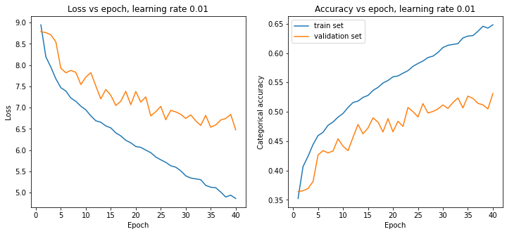

```python
# plot learning curves

fig = plt.figure(figsize=(12, 5))

fig.add_subplot(121)
plt.plot(np.arange(1,41),losses_train, label='train set')
plt.plot(np.arange(1,41),losses_val, label='validation set')
plt.xlabel("Epoch")
plt.ylabel("Loss")
plt.title("Loss vs epoch, learning rate 0.01")

fig.add_subplot(122)
plt.plot(np.arange(1,41),accs_train, label='train set')
plt.plot(np.arange(1,41),accs_val, label='validation set')
plt.xlabel("Epoch")
plt.ylabel("Categorical accuracy")
plt.title("Accuracy vs epoch, learning rate 0.01")
plt.legend()
plt.show()
```

We can see that the loss is decreasing and the accuracies are increasing for both the training and validation sets. There are signs of overfitting because the difference between the metrics for the training set and validation set become more significant as we go through more epochs. The validation accuracy does not seem to have plateau'ed or decreasing yet after 40 epochs - this suggests we could expect even better reesults if we train the model for longer in 1.3. for 80 epochs. This would be desirable because for now we have a validation accuracy of 53%, even though it is much better than 10%, which is the random assignment probability.

Moreover, the performance of the model is affected by the choices of batch size, the optimizer (primitive SGD), the number of epochs we are running the model for and the hyperparameter of the model: learning rate. We will vary the learning rate in the next subsection and see whether it yields better results.

### 1.1.2.

Train the model with 0.1 and 0.0001 learning rates.

#### learning rate = 0.1

```python
(x_train, y_train), (x_val, y_val) = load_data()  # load the CIFAR-10 dataset

epochs = 40
learning_rate = 0.1
W, b, losses_train_1, accs_train_1, losses_val_1, accs_val_1 = train_mlp(x_train, y_train, x_val, y_val,
                                                                 epochs, learning_rate, batch_size=128)
```

```
epoch 1 train loss: 9.787093365702226 train acc: 0.2915865384615385 val loss: 9.531320423840254 val acc: 0.3101
epoch 2 train loss: 8.12436112531268 train acc: 0.41193910256410254 val loss: 9.339284813184573 val acc: 0.324
epoch 3 train loss: 7.474268243708974 train acc: 0.45899439102564105 val loss: 8.18016339347121 val acc: 0.4079
epoch 4 train loss: 7.046131296990825 train acc: 0.48998397435897434 val loss: 8.32522626482984 val acc: 0.3974
epoch 5 train loss: 6.696038706429452 train acc: 0.5153245192307693 val loss: 7.703528244721342 val acc: 0.4424
epoch 6 train loss: 6.397422180567215 train acc: 0.5369391025641026 val loss: 7.486624713261248 val acc: 0.4581
epoch 7 train loss: 6.13256952509903 train acc: 0.5561097756410256 val loss: 7.326364779188778 val acc: 0.4697
epoch 8 train loss: 5.906462294673224 train acc: 0.5724759615384616 val loss: 7.563991577985856 val acc: 0.4525
epoch 9 train loss: 5.671222214058858 train acc: 0.5895032051282051 val loss: 7.845828013768398 val acc: 0.4321
epoch 10 train loss: 5.4639341900822025 train acc: 0.6045072115384615 val loss: 7.4576121389895125 val acc: 0.4602
epoch 11 train loss: 5.2339524171521585 train acc: 0.6211538461538462 val loss: 7.326364779188784 val acc: 0.4697
epoch 12 train loss: 5.0726053971543035 train acc: 0.6328325320512821 val loss: 7.399586990446018 val acc: 0.4644
epoch 13 train loss: 4.832937267963663 train acc: 0.6501802884615384 val loss: 6.881505307022142 val acc: 0.5019
epoch 14 train loss: 4.658306102237001 train acc: 0.6628205128205128 val loss: 7.001700257576473 val acc: 0.4932
epoch 15 train loss: 4.453232102548476 train acc: 0.6776642628205128 val loss: 7.068014713054721 val acc: 0.4884
epoch 16 train loss: 4.200556580665049 train acc: 0.6959535256410256 val loss: 6.813809300388073 val acc: 0.5068
epoch 17 train loss: 4.0137482813536405 train acc: 0.7094751602564102 val loss: 7.110842798884421 val acc: 0.4853
epoch 18 train loss: 3.8366263383028265 train acc: 0.7222956730769231 val loss: 7.273865835268506 val acc: 0.4735
epoch 19 train loss: 3.621035723245654 train acc: 0.737900641025641 val loss: 6.786178277272126 val acc: 0.5088
epoch 20 train loss: 3.448341828771111 train acc: 0.7504006410256411 val loss: 6.835914118880834 val acc: 0.5052
epoch 21 train loss: 3.226662646921571 train acc: 0.7664463141025641 val loss: 6.925714944007662 val acc: 0.4987
epoch 22 train loss: 3.037917076358044 train acc: 0.780108173076923 val loss: 6.642496957069225 val acc: 0.5192
epoch 23 train loss: 2.867990712243666 train acc: 0.7924078525641025 val loss: 6.612102831641688 val acc: 0.5214
epoch 24 train loss: 2.6571048987987864 train acc: 0.8076722756410256 val loss: 6.8538742839062 val acc: 0.5039
epoch 25 train loss: 2.5107025427458445 train acc: 0.8182692307692307 val loss: 6.816572402699656 val acc: 0.5066
epoch 26 train loss: 2.3216802191462977 train acc: 0.8319511217948717 val loss: 6.793086033051117 val acc: 0.5083
epoch 27 train loss: 2.1044290858730315 train acc: 0.8476762820512821 val loss: 6.7005221056127064 val acc: 0.515
epoch 28 train loss: 1.973801652873056 train acc: 0.8571314102564103 val loss: 6.739205537975017 val acc: 0.5122
epoch 29 train loss: 1.7656833697883412 train acc: 0.8721955128205128 val loss: 6.852492732750394 val acc: 0.504
epoch 30 train loss: 1.687639013631576 train acc: 0.8778445512820513 val loss: 6.9920293994858715 val acc: 0.4939
epoch 31 train loss: 1.514668366121012 train acc: 0.8903645833333333 val loss: 6.747494844909801 val acc: 0.5116
epoch 32 train loss: 1.3190039696570597 train acc: 0.9045272435897436 val loss: 6.68946969636632 val acc: 0.5158
epoch 33 train loss: 1.2819190628307964 train acc: 0.9072115384615385 val loss: 6.652167815159804 val acc: 0.5185
epoch 34 train loss: 1.1399447553541247 train acc: 0.9174879807692308 val loss: 7.047291445717795 val acc: 0.4899
epoch 35 train loss: 1.0679889659897295 train acc: 0.9226963141025641 val loss: 6.862163590840956 val acc: 0.5033
epoch 36 train loss: 0.9907748689410131 train acc: 0.9282852564102564 val loss: 6.8400587723482165 val acc: 0.5049
epoch 37 train loss: 0.9166050552884828 train acc: 0.9336538461538462 val loss: 7.156433987025733 val acc: 0.482
epoch 38 train loss: 0.7585790717228307 train acc: 0.9450921474358974 val loss: 6.849729630438793 val acc: 0.5042
epoch 39 train loss: 0.7209406588245323 train acc: 0.9478165064102564 val loss: 6.728153128728636 val acc: 0.513
epoch 40 train loss: 0.6788741973499628 train acc: 0.9508613782051282 val loss: 6.823480158478653 val acc: 0.5061
```

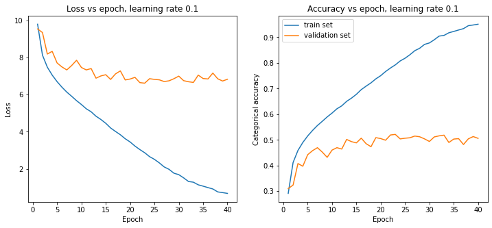

```python
# plot learning curves
fig = plt.figure(figsize=(12, 5))

fig.add_subplot(121)
plt.plot(np.arange(1,41),losses_train_1, label='train set')
plt.plot(np.arange(1,41),losses_val_1, label='validation set')
plt.xlabel("Epoch")
plt.ylabel("Loss")
plt.title("Loss vs epoch, learning rate 0.1")

fig.add_subplot(122)
plt.plot(np.arange(1,41),accs_train_1, label='train set')
plt.plot(np.arange(1,41),accs_val_1, label='validation set')
plt.xlabel("Epoch")
plt.ylabel("Categorical accuracy")
plt.title("Accuracy vs epoch, learning rate 0.1")
plt.legend()
plt.show()
```

We can see that the loss is decreasing and the accuracies are increasing for both the training and validation sets. Clearly, increasing the learning rate resulted in more overfitting than the previous model with a smaller learning rate 0.01 - the model is more sensitive to the training set.

Morover, the plots show that the difference betweeen the training and validation metrics is much more significant: the validation accuracy is lower and the loss is higher than the training accuracy and loss. It is overfitting to the point that the validation loss and the validation accuracy both plateau around epoch 10. The validation accuracy is oscillating around 50 and never reaches the 53% reached by the model above trained with leearning rate 0.01, whilee thee training accuracy is above 90%. Therefore, this learning rate is not the optimal choice for this model and we should consider decreasing it.

#### learning rate = 0.0001

```python
(x_train, y_train), (x_val, y_val) = load_data()  # load the CIFAR-10 dataset

epochs = 40
learning_rate = 0.0001
W, b, losses_train_0001, accs_train_0001, losses_val_0001, accs_val_0001 = train_mlp(x_train, y_train,
                                                                                     x_val, y_val, epochs,
                                                                                     learning_rate, batch_size=128)
```

```
epoch 1 train loss: 12.01246452831412 train acc: 0.1305088141025641 val loss: 11.574634583263085 val acc: 0.1622
epoch 2 train loss: 11.280729501085442 train acc: 0.1834735576923077 val loss: 11.005435507075013 val acc: 0.2034
epoch 3 train loss: 10.942537291072789 train acc: 0.20795272435897436 val loss: 10.800965936017167 val acc: 0.2182
epoch 4 train loss: 10.729160700303764 train acc: 0.2233974358974359 val loss: 10.621364285763642 val acc: 0.2312
epoch 5 train loss: 10.563385631729629 train acc: 0.23539663461538463 val loss: 10.466630556314435 val acc: 0.2424
epoch 6 train loss: 10.464584797871606 train acc: 0.24254807692307692 val loss: 10.36992197540868 val acc: 0.2494
epoch 7 train loss: 10.363569939725428 train acc: 0.24985977564102563 val loss: 10.258016331789173 val acc: 0.2575
epoch 8 train loss: 10.362462927581365 train acc: 0.24993990384615383 val loss: 10.180649467064589 val acc: 0.2631
epoch 9 train loss: 10.25176171317461 train acc: 0.2579527243589744 val loss: 10.126768971988525 val acc: 0.267
epoch 10 train loss: 10.131097389471233 train acc: 0.2666866987179487 val loss: 10.085322437314638 val acc: 0.27
epoch 11 train loss: 10.076023535303866 train acc: 0.2706730769230769 val loss: 9.996903163343664 val acc: 0.2764
epoch 12 train loss: 10.029805778289045 train acc: 0.27401842948717947 val loss: 9.965127486760354 val acc: 0.2787
epoch 13 train loss: 9.984695033418289 train acc: 0.27728365384615383 val loss: 9.897431480126333 val acc: 0.2836
epoch 14 train loss: 9.873717065975525 train acc: 0.2853165064102564 val loss: 9.838024780427096 val acc: 0.2879
epoch 15 train loss: 9.865137721858982 train acc: 0.2859375 val loss: 9.796578245753189 val acc: 0.2909
epoch 16 train loss: 9.813938410195865 train acc: 0.28964342948717947 val loss: 9.779999631883639 val acc: 0.2921
epoch 17 train loss: 9.699639406320879 train acc: 0.29791666666666666 val loss: 9.694343460224268 val acc: 0.2983
epoch 18 train loss: 9.699085900248855 train acc: 0.2979567307692308 val loss: 9.665330885952542 val acc: 0.3004
epoch 19 train loss: 9.64401204608149 train acc: 0.301943108974359 val loss: 9.59072712353954 val acc: 0.3058
epoch 20 train loss: 9.566797949032777 train acc: 0.3075320512820513 val loss: 9.576911611981576 val acc: 0.3068
epoch 21 train loss: 9.538015633287014 train acc: 0.3096153846153846 val loss: 9.539609730775073 val acc: 0.3095
epoch 22 train loss: 9.534971349890826 train acc: 0.3098357371794872 val loss: 9.51474180997074 val acc: 0.3113
epoch 23 train loss: 9.466890103030677 train acc: 0.3147636217948718 val loss: 9.48020303107583 val acc: 0.3138
epoch 24 train loss: 9.463292313562453 train acc: 0.3150240384615385 val loss: 9.419414780220778 val acc: 0.3182
epoch 25 train loss: 9.398808856170502 train acc: 0.3196915064102564 val loss: 9.404217717507018 val acc: 0.3193
epoch 26 train loss: 9.37805237846924 train acc: 0.32119391025641025 val loss: 9.358626529365726 val acc: 0.3226
epoch 27 train loss: 9.323808783409932 train acc: 0.3251201923076923 val loss: 9.36277118283311 val acc: 0.3223
epoch 28 train loss: 9.307203601248917 train acc: 0.32632211538461536 val loss: 9.332377057405589 val acc: 0.3245
epoch 29 train loss: 9.280358556755269 train acc: 0.3282652243589744 val loss: 9.284022766952715 val acc: 0.328
epoch 30 train loss: 9.26347662155825 train acc: 0.3294871794871795 val loss: 9.252247090369389 val acc: 0.3303
epoch 31 train loss: 9.24659468636122 train acc: 0.3307091346153846 val loss: 9.227379169565054 val acc: 0.3321
epoch 32 train loss: 9.299731269276457 train acc: 0.32686298076923076 val loss: 9.206655902228107 val acc: 0.3336
epoch 33 train loss: 9.200653682382415 train acc: 0.3340344551282051 val loss: 9.195603492981734 val acc: 0.3344
epoch 34 train loss: 9.197609398986229 train acc: 0.3342548076923077 val loss: 9.187314186046958 val acc: 0.335
epoch 35 train loss: 9.166613058952322 train acc: 0.33649839743589743 val loss: 9.166590918710012 val acc: 0.3365
epoch 36 train loss: 9.132572435522249 train acc: 0.33896233974358975 val loss: 9.136196793282485 val acc: 0.3387
epoch 37 train loss: 9.124546597477758 train acc: 0.3395432692307692 val loss: 9.089224053985408 val acc: 0.3421
epoch 38 train loss: 9.04733250042904 train acc: 0.3451322115384615 val loss: 9.091987156296998 val acc: 0.3419
epoch 39 train loss: 9.121502314081575 train acc: 0.3397636217948718 val loss: 9.0505406216231 val acc: 0.3449
epoch 40 train loss: 9.115136994253188 train acc: 0.340224358974359 val loss: 9.039488212376739 val acc: 0.3457
```

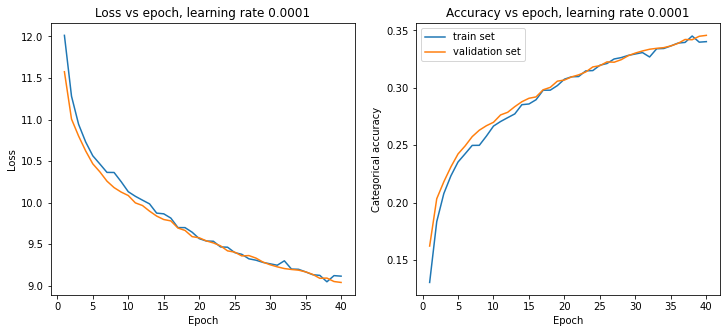

```python
# plot learning curves
fig = plt.figure(figsize=(12, 5))

fig.add_subplot(121)
plt.plot(np.arange(1,41),losses_train_0001, label='train set')
plt.plot(np.arange(1,41),losses_val_0001, label='validation set')
plt.xlabel("Epoch")
plt.ylabel("Loss")
plt.title("Loss vs epoch, learning rate 0.0001")

fig.add_subplot(122)
plt.plot(np.arange(1,41),accs_train_0001, label='train set')
plt.plot(np.arange(1,41),accs_val_0001, label='validation set')
plt.xlabel("Epoch")
plt.ylabel("Categorical accuracy")
plt.title("Accuracy vs epoch, learning rate 0.0001")
plt.legend()
plt.show()
```

With this learning rate, the model not overfitting anymore, but is learning too slowly. The accuracies over the same number of epochs increase and the losses decrease very slowly, compared to the model with a 0.01 learning rate. This suggests that the optimal learning rate is 0.01, one that strikes a good balance between overfitting and slow learning. In the next subsection we will run the training for longer to find out the optimal number of training epochs.

### 1.1.3.

Train the model for 80 epochs as in 1.1.1., i.e., with learning rate 0.01 and 128 batches.

```python
(x_train, y_train), (x_val, y_val) = load_data()  # load the CIFAR-10 dataset

epochs = 80
learning_rate = 0.01
W, b, losses_train_40, accs_train_40, losses_val_40, accs_val_40 = train_mlp(x_train, y_train, x_val, y_val,
                                                                 epochs, learning_rate, batch_size=128)
```

```
epoch 1 train loss: 8.869380298270174 train acc: 0.3580128205128205 val loss: 8.888899136394873 val acc: 0.3566
epoch 2 train loss: 8.184970040200382 train acc: 0.4075520833333333 val loss: 8.474433789655874 val acc: 0.3866
epoch 3 train loss: 7.890228056842384 train acc: 0.42888621794871795 val loss: 8.598773393677588 val acc: 0.3776
epoch 4 train loss: 7.72805077773648 train acc: 0.440625 val loss: 8.362528146036373 val acc: 0.3947
epoch 5 train loss: 7.546224033073367 train acc: 0.4537860576923077 val loss: 8.051679135982134 val acc: 0.4172
epoch 6 train loss: 7.364120535374256 train acc: 0.46696714743589746 val loss: 7.9646414131669125 val acc: 0.4235
epoch 7 train loss: 7.189489369647581 train acc: 0.4796073717948718 val loss: 7.569517782609043 val acc: 0.4521
epoch 8 train loss: 7.111721766526832 train acc: 0.4852363782051282 val loss: 7.642739993866277 val acc: 0.4468
epoch 9 train loss: 6.964212398329825 train acc: 0.49591346153846155 val loss: 7.8168154394967 val acc: 0.4342
epoch 10 train loss: 6.90388023647814 train acc: 0.5002804487179487 val loss: 7.586096396478599 val acc: 0.4509
epoch 11 train loss: 6.8034188844040075 train acc: 0.5075520833333333 val loss: 7.374719069641664 val acc: 0.4662
epoch 12 train loss: 6.678880018196402 train acc: 0.5165665064102564 val loss: 7.497677122507628 val acc: 0.4573
epoch 13 train loss: 6.654248997990897 train acc: 0.518349358974359 val loss: 7.4299811158735665 val acc: 0.4622
epoch 14 train loss: 6.583953726842603 train acc: 0.5234375 val loss: 7.373337518485858 val acc: 0.4663
epoch 15 train loss: 6.533307921251507 train acc: 0.5271033653846153 val loss: 7.340180290746747 val acc: 0.4687
epoch 16 train loss: 6.40018971092738 train acc: 0.536738782051282 val loss: 7.214459135569228 val acc: 0.4778
epoch 17 train loss: 6.344285597651966 train acc: 0.5407852564102564 val loss: 7.007226462199679 val acc: 0.4928
epoch 18 train loss: 6.254064107910448 train acc: 0.5473157051282052 val loss: 7.12189520813082 val acc: 0.4845
epoch 19 train loss: 6.174635986573607 train acc: 0.5530649038461538 val loss: 7.051436099185163 val acc: 0.4896
epoch 20 train loss: 6.138104585819369 train acc: 0.5557091346153846 val loss: 7.22274844250401 val acc: 0.4772
epoch 21 train loss: 6.014672731755831 train acc: 0.5646434294871795 val loss: 7.356758904616305 val acc: 0.4675
epoch 22 train loss: 5.9745435415333885 train acc: 0.567548076923077 val loss: 6.993410950641684 val acc: 0.4938
epoch 23 train loss: 5.917532416113902 train acc: 0.5716746794871795 val loss: 6.7309162310402275 val acc: 0.5128
epoch 24 train loss: 5.8054474365270625 train acc: 0.5797876602564103 val loss: 6.85663738621781 val acc: 0.5037
epoch 25 train loss: 5.7752813556012175 train acc: 0.5819711538461538 val loss: 6.7737443168699585 val acc: 0.5097
epoch 26 train loss: 5.695022975156309 train acc: 0.5877804487179488 val loss: 7.130184515065608 val acc: 0.4839
epoch 27 train loss: 5.61587160685548 train acc: 0.5935096153846153 val loss: 7.24070860752937 val acc: 0.4759
epoch 28 train loss: 5.5239895988978684 train acc: 0.6001602564102564 val loss: 6.741968640286617 val acc: 0.512
epoch 29 train loss: 5.540041274986848 train acc: 0.5989983974358974 val loss: 6.772362765714147 val acc: 0.5098
epoch 30 train loss: 5.413011631455097 train acc: 0.608193108974359 val loss: 6.714337617170674 val acc: 0.514
epoch 31 train loss: 5.350465445315272 train acc: 0.6127203525641025 val loss: 6.708811412547487 val acc: 0.5144
epoch 32 train loss: 5.33219974493815 train acc: 0.614042467948718 val loss: 6.762691907623573 val acc: 0.5105
epoch 33 train loss: 5.272144336122491 train acc: 0.6183894230769231 val loss: 6.917425637072841 val acc: 0.4993
epoch 34 train loss: 5.193546473893687 train acc: 0.6240785256410256 val loss: 6.910517881293896 val acc: 0.4998
epoch 35 train loss: 5.117439388989041 train acc: 0.6295873397435897 val loss: 6.845584976971415 val acc: 0.5045
epoch 36 train loss: 5.023896862815323 train acc: 0.6363581730769231 val loss: 6.620392138576466 val acc: 0.5208
epoch 37 train loss: 5.005077656366181 train acc: 0.6377203525641025 val loss: 6.536117518072859 val acc: 0.5269
epoch 38 train loss: 5.005907915474231 train acc: 0.6376602564102564 val loss: 6.703285207924301 val acc: 0.5148
epoch 39 train loss: 4.892992676779333 train acc: 0.6458333333333334 val loss: 6.627299894355453 val acc: 0.5203
epoch 40 train loss: 4.837088563503921 train acc: 0.6498798076923077 val loss: 6.585853359681541 val acc: 0.5233
```

[output cut: 25 more lines]

```
epoch 66 train loss: 3.3135631002308803 train acc: 0.76015625 val loss: 6.462895306815649 val acc: 0.5322
epoch 67 train loss: 3.2557217157033467 train acc: 0.7643429487179487 val loss: 6.381383788623656 val acc: 0.5381
epoch 68 train loss: 3.2006478615359835 train acc: 0.7683293269230769 val loss: 6.357897418975116 val acc: 0.5398
epoch 69 train loss: 3.249079642838941 train acc: 0.764823717948718 val loss: 6.439408937167102 val acc: 0.5339
epoch 70 train loss: 3.1331201207478583 train acc: 0.7732171474358974 val loss: 6.374476032844673 val acc: 0.5386
epoch 71 train loss: 3.058950307095325 train acc: 0.7785857371794872 val loss: 6.272241247315735 val acc: 0.546
epoch 72 train loss: 3.012455797044492 train acc: 0.7819511217948718 val loss: 6.447698244101883 val acc: 0.5333
epoch 73 train loss: 2.9241715785550983 train acc: 0.7883413461538461 val loss: 6.377239135156264 val acc: 0.5384
epoch 74 train loss: 2.8920682263771367 train acc: 0.7906650641025641 val loss: 6.30954312852224 val acc: 0.5433
epoch 75 train loss: 2.840868914714012 train acc: 0.7943709935897436 val loss: 6.446316692946089 val acc: 0.5334
epoch 76 train loss: 2.7581197569449554 train acc: 0.8003605769230769 val loss: 6.255662633446177 val acc: 0.5472
epoch 77 train loss: 2.6750938461398817 train acc: 0.8063701923076924 val loss: 6.286056758873698 val acc: 0.545
epoch 78 train loss: 2.7049831740297132 train acc: 0.8042067307692308 val loss: 6.279149003094712 val acc: 0.5455
epoch 79 train loss: 2.6388391984216732 train acc: 0.8089943910256411 val loss: 6.2073083429933025 val acc: 0.5507
epoch 80 train loss: 2.5472339435000753 train acc: 0.815625 val loss: 6.6079581781742975 val acc: 0.5217
```

[figure not shown]

```python
# plot learning curves
fig = plt.figure(figsize=(12, 5))

fig.add_subplot(121)
plt.plot(np.arange(1,81),losses_train_40, label='train set')
plt.plot(np.arange(1,81),losses_val_40, label='validation set')
plt.xlabel("Epoch")
plt.ylabel("Loss")
plt.title("Loss vs epoch, learning rate 0.01")

fig.add_subplot(122)
plt.plot(np.arange(1,81),accs_train_40, label='train set')
plt.plot(np.arange(1,81),accs_val_40, label='validation set')
plt.xlabel("Epoch")
plt.ylabel("Categorical accuracy")
plt.title("Accuracy vs epoch, learning rate 0.01")
plt.legend()
plt.show()

# NOTE: TITLES ARE WRONG, THIS IS WITH LEARNING RATE 0.01
```

We see that running the training for 80 epochs is too long as the model starts overfitting after 50-60 epochs, it oscillates around a 53-55% validation accuracy. The optimal number of epochs is when the validation accuracy stops increasing - in our case the validation accuracy keeps increasing marginally, reaching the maximal validation accuracy of 55.07% at epoch 79, but this is only marginally better than the results, at, say epoch 50 which would save us a lot of time and computational power.

Morover, recall that we use the learning rate $\eta$ when weupdate the parameter (weight and bias) values using the update rule

$$ \theta_{t+1} = \theta_t - \eta \nabla_\theta L (\theta_t; \mathcal{D}_{train}).$$

It is cleear then that when the learning rate is too large such as 0.1, the parameters are changed more significantly towards the dataset we compute the gradients for, this results in overfitting. If if it is too small, there will not be significant changes in the weights and biases from their random initialisations - the model will fail to minimise the loss function efficiently and the accuracies will be low, even for long periods of training, as shown with learning rate 0.0001.

### 1.2. CNN

In this task, I will implement a CNN with 4 hidden layers, first 3 2D-convolutional, 1 dense and a dense output layer:

- 3 convolutional layers: 3x3 feature maps, 32, 64, 64
- between convolutional layers: 2x2 max pooling layers
- dense layer of 64 feature maps
- flattning to a 1-D vector
- dense output layer: outputs a probability vector with 10 entries, corresponding to each class.

We will modify the model in subsequent subsections to evaluate different methods to prevent overfitting.

```python
from tensorflow.keras.models import Sequential
from tensorflow.keras.layers import Conv2D, MaxPooling2D, Flatten, Dense, Dropout
from tensorflow.keras.regularizers import l1, l2, l1_l2
from tensorflow.keras import optimizers
```

```python
def load_data():
    (x_train, y_train), (x_val, y_val) = tf.keras.datasets.cifar10.load_data()
    x_train = x_train.astype('float32') / 255
    x_val = x_val.astype('float32') / 255
    # convert labels to categorical samples
    y_train = tf.keras.utils.to_categorical(y_train, num_classes=10)
    y_val = tf.keras.utils.to_categorical(y_val, num_classes=10)
    return ((x_train, y_train), (x_val, y_val))

(x_train, y_train), (x_val, y_val) = load_data()  # load the CIFAR-10 dataset
```

Print the dimensions of the data to properly implement the input shape in the first layer of the CNN model.

```python
print(x_train.shape)
print(y_train.shape)
print(x_val.shape)
print(y_val.shape)
```

```
(50000, 32, 32, 3)
(50000, 10)
(10000, 32, 32, 3)
(10000, 10)
```

Modify the sgd optimizer to have 0.1 learning rate:

```python
sgd = optimizers.SGD(lr=0.1)
```

```python
def get_model():
    model = Sequential([
        # params:
        # layer with filters (the number of output filters in the convolution),
        # kernel width (height and width of the 2D convolution window) (3x3)

        Conv2D(32, (3, 3), activation='relu', input_shape=(32,32,3)),  # 3x3 feature maps
        MaxPooling2D(pool_size=(2,2)),  # 2x2 maximum pooling layers between conv layers

        Conv2D(64, (3, 3), activation='relu'),  # 3x3 feature maps
        MaxPooling2D(pool_size=(2,2)),  # 2x2 maximum pooling layers between conv layers

        Conv2D(64, (3, 3), activation='relu'),  # 3x3 feature maps

        Dense(64, activation='relu'),

        Flatten(),
        Dense(10, activation='softmax')  # 10 outputs, softmax activation
    ])
    model.compile(loss='categorical_crossentropy', optimizer=sgd, metrics=['accuracy'])  # compile the model
    return model
```

```python
model = get_model()
model.summary()
```

```
Model: "sequential_4"
_________________________________________________________________
Layer (type)                 Output Shape              Param #
=================================================================
conv2d_15 (Conv2D)           (None, 30, 30, 32)        896
_________________________________________________________________
max_pooling2d_13 (MaxPooling (None, 15, 15, 32)        0
_________________________________________________________________
conv2d_16 (Conv2D)           (None, 13, 13, 64)        18496
_________________________________________________________________
max_pooling2d_14 (MaxPooling (None, 6, 6, 64)          0
_________________________________________________________________
conv2d_17 (Conv2D)           (None, 4, 4, 64)          36928
_________________________________________________________________
dense_5 (Dense)              (None, 4, 4, 64)          4160
_________________________________________________________________
flatten_4 (Flatten)          (None, 1024)              0
_________________________________________________________________
dense_6 (Dense)              (None, 10)                10250
=================================================================
Total params: 70,730
Trainable params: 70,730
Non-trainable params: 0
_________________________________________________________________
```

- The first layer outputs 32 filters (channels) of size 30x30 since it is reduced since we use 3x3 feature maps,
- The 2x2 pooling layer then reduces the dimensions by half, but the number of filters is unchanged - it remains 32

This is repeated for all layers, and the data is flattened before the last dense layer so that it outputs a length-10 probability vector for the input image data belonging to each class.

```python
# shapes of the variables at each layer
# check we indeed have 3x3 feature maps in the first two entries
print(model.layers[0].kernel.shape)
print(model.layers[0].bias.shape)

print(model.layers[2].kernel.shape)
print(model.layers[2].bias.shape)
```

```
(3, 3, 3, 32)
(32,)
(3, 3, 32, 64)
(64,)
```

Now we aggregate and shuffle the training and test data.

```python
val_data = tf.data.Dataset.from_tensor_slices((x_val.astype(np.float32), y_val.astype(np.float32)))
val_data = val_data.batch(128)

train_data.element_spec
```

```
(TensorSpec(shape=(None, 32, 32, 3), dtype=tf.float32, name=None),
 TensorSpec(shape=(None, 10), dtype=tf.float32, name=None))
```

Now train the model for 40 epochs:

```python
history = model.fit(x_train, y_train, epochs=40, verbose=1, validation_data=val_data, batch_size=128)
```

```python
# define the plotting function we will use throughout this task
def plot_learning_curves():
    fig = plt.figure(figsize=(12, 5))

    fig.add_subplot(121)
    plt.plot(history.history['loss'], label='Train')
    plt.plot(history.history['val_loss'], label='Validation')
    plt.xlabel("Epoch")
    plt.ylabel("Cross entropy loss")
    plt.title("Loss vs epoch")
    plt.legend()

    fig.add_subplot(122)
    plt.plot(history.history['accuracy'], label='Train')
    plt.plot(history.history['val_accuracy'], label='Validation')
    plt.xlabel("Epoch")
    plt.ylabel("Categorical accuracy")
    plt.title("Accuracy vs epoch")
    plt.legend()

    plt.show()
```

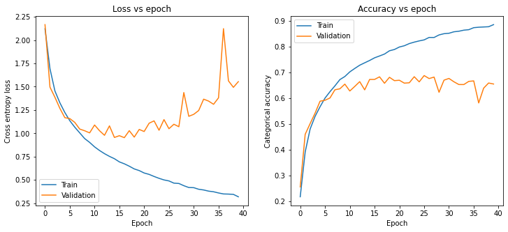

```python
# train_data.batch(128) the val data before
plot_learning_curves()
```

We clearly see that 40 epochs is too long and we are overfitting the model with our data - from around 15/20 epochs, the validation loss is increasing and the validation accuracy is decreasing. In the next subsections, we will look at ways to reduce overfitting, notably regularisation and dropout.

#### 1.2.2. Include l2 regularisation

We now include the $\mathcal{l}_2$ regularisation in the CNN model, which adds a penalty term to the loss functions to control the weight sizes.

The goal of regularisation is to refuce overfitting by preventing the weights from getting too large. It is done by adding a penalty term to the loss function, which in our case is the cross entropy. The penalty term is a sum of squares of the weights multiplied by a penalty coefficient $\alpha_2$ that is a hyperparameter that controls how much we want to penalise for large weights. Given our unconstraineed loss function $L_0$, the regularised loss function is therefore

$$ L(\textbf{w},\alpha) = L_0(\textbf{w}) + \alpha_2 \sum_i w_i^2. $$

```python
(x_train, y_train), (x_val, y_val) = load_data()  # load the CIFAR-10 dataset

val_data = tf.data.Dataset.from_tensor_slices((x_val.astype(np.float32), y_val.astype(np.float32)))
val_data = val_data.batch(128)
```

```python
def get_model_l2regul(regul_coeff):
    model = Sequential([
        # layer with filters (the number of output filters in the convolution),
        # kernel width (height and width of the 2D convolution window) (3x3)

        Conv2D(32, (3, 3), activation='relu', input_shape=(32,32,3), kernel_regularizer=l2(regul_coeff)),  # 3x3 feature maps
        MaxPooling2D(pool_size=(2,2)),  # 2x2 maximum pooling layers

        Conv2D(64, (3, 3), activation='relu', kernel_regularizer=l2(regul_coeff)),  # 3x3 feature maps
        MaxPooling2D(pool_size=(2,2)),  # 2x2 maximum pooling layers

        Conv2D(64, (3, 3), activation='relu', kernel_regularizer=l2(regul_coeff)),  # 3x3 feature maps

        Dense(64, activation='relu', kernel_regularizer=l2(regul_coeff)),

        Flatten(),
        Dense(10, kernel_regularizer=l2(regul_coeff), activation='softmax')  # 10 outputs, softmax activation
    ])
    model.compile(loss='categorical_crossentropy', optimizer=sgd, metrics=['accuracy'])
    return model
```

```python
model_l2 = get_model_l2regul(regul_coeff=0.0005)
model_l2.summary()
```

```
Model: "sequential_7"
_________________________________________________________________
Layer (type)                 Output Shape              Param #
=================================================================
conv2d_24 (Conv2D)           (None, 30, 30, 32)        896
_________________________________________________________________
max_pooling2d_19 (MaxPooling (None, 15, 15, 32)        0
_________________________________________________________________
conv2d_25 (Conv2D)           (None, 13, 13, 64)        18496
_________________________________________________________________
max_pooling2d_20 (MaxPooling (None, 6, 6, 64)          0
_________________________________________________________________
conv2d_26 (Conv2D)           (None, 4, 4, 64)          36928
_________________________________________________________________
dense_11 (Dense)             (None, 4, 4, 64)          4160
_________________________________________________________________
flatten_7 (Flatten)          (None, 1024)              0
_________________________________________________________________
dense_12 (Dense)             (None, 10)                10250
=================================================================
Total params: 70,730
Trainable params: 70,730
Non-trainable params: 0
_________________________________________________________________
```

```python
history = model_l2.fit(x_train, y_train, epochs=40, verbose=1,
                       validation_data=val_data, batch_size=128)
```

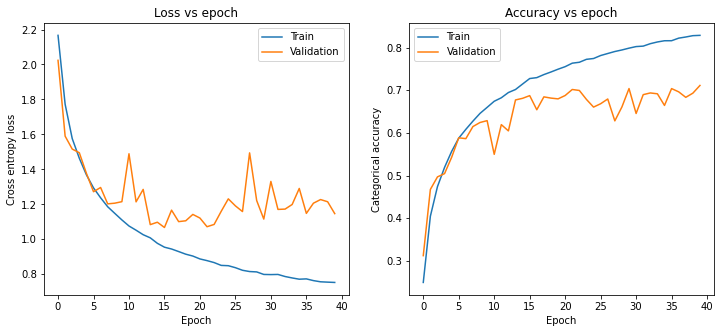

```python
plot_learning_curves()
```

Notice that we have not entirely fixed the overfitting problem by introducing $\mathcal{l}_2$ regularisation - although the validation loss grows less and the validation accuracy does not decrease when the number of epochs grow larger comparing to the non-regularised model, the difference between the train and validation metrics is still significant. The model is still overfitting the training data. A way to fix this is to introduce sparsity in out data, which will be thee focus of the next subsection.

#### 1.2.3. Introduce 2 models: dropout and l1 regularisation

In this subsection, we will implement two other methods to reduce overfitting: dropout and $\mathcal{l}_1$ regularisation.

First, implement the model with a dropout rate of 0.5. This means that we randomly replace every column of the weight (kernel) matrix $\textbf{W}^k$ at layer $k$ with zeros with probability 0.5. This creates a regularisation effect as some specific connections between the training data are 'broken up', and the capacity is reduced. This makes the model less dependeent on combinations that are specific to the training data - it is more robust and less prone to overfitting. Also, dropout is most effective between dense layers, but we implement it between both the convolutional and dense layers to see a more significant effect on the modeel performance.

```python
def get_model_drop(rate):
    model = Sequential([
        # layer with filters (the number of output filters in the convolution),
        # kernel width (height and width of the 2D convolution window) (3x3)

        Conv2D(32, (3, 3), activation='relu', input_shape=(32,32,3)),  # 3x3 feature maps
        MaxPooling2D(pool_size=(2,2)),  # 2x2 maximum pooling layers
        Dropout(rate),

        Conv2D(64, (3, 3), activation='relu'),  # 3x3 feature maps
        MaxPooling2D(pool_size=(2,2)),  # 2x2 maximum pooling layers
        Dropout(rate),

        Conv2D(64, (3, 3), activation='relu'),  # 3x3 feature maps
        Dropout(rate),

        Dense(64, activation='relu'),
        Dropout(rate),

        Flatten(),
        Dense(10, activation='softmax')  # 10 outputs, softmax activation
    ])
    model.compile(loss='categorical_crossentropy', optimizer=sgd, metrics=['accuracy'])  # compile the model
    return model
```

```python
model_drop = get_model_drop(rate=0.5)
model_drop.summary()
```

```
Model: "sequential_9"
_________________________________________________________________
Layer (type)                 Output Shape              Param #
=================================================================
conv2d_30 (Conv2D)           (None, 30, 30, 32)        896
_________________________________________________________________
max_pooling2d_23 (MaxPooling (None, 15, 15, 32)        0
_________________________________________________________________
dropout_4 (Dropout)          (None, 15, 15, 32)        0
_________________________________________________________________
conv2d_31 (Conv2D)           (None, 13, 13, 64)        18496
_________________________________________________________________
max_pooling2d_24 (MaxPooling (None, 6, 6, 64)          0
_________________________________________________________________
dropout_5 (Dropout)          (None, 6, 6, 64)          0
_________________________________________________________________
conv2d_32 (Conv2D)           (None, 4, 4, 64)          36928
_________________________________________________________________
dropout_6 (Dropout)          (None, 4, 4, 64)          0
_________________________________________________________________
dense_15 (Dense)             (None, 4, 4, 64)          4160
_________________________________________________________________
dropout_7 (Dropout)          (None, 4, 4, 64)          0
_________________________________________________________________
flatten_9 (Flatten)          (None, 1024)              0
_________________________________________________________________
dense_16 (Dense)             (None, 10)                10250
=================================================================
Total params: 70,730
Trainable params: 70,730
Non-trainable params: 0
_________________________________________________________________
```

```python
(x_train, y_train), (x_val, y_val) = load_data()  # load the CIFAR-10 dataset

val_data = tf.data.Dataset.from_tensor_slices((x_val.astype(np.float32), y_val.astype(np.float32)))
val_data = val_data.batch(128)
```

```python
history = model_drop.fit(x_train, y_train, epochs=40, verbose=1,
                       validation_data=val_data, batch_size=128)
```

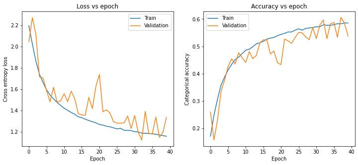

```python
plot_learning_curves()
```

We now implement the model with $\mathcal{l}_1$ kernel regularisation. It is essentially the same as $l_2$, only we are penalising the sum of the absolute values of the weights rather than the squares of weights. The loss function is thus

$$ L(\textbf{w},\alpha) = L_0(\textbf{w}) + \alpha_1 \sum_i |w_i|. $$

```python
def get_model_l1regul(regul_coeff):
    model = Sequential([
        # layer with filters (the number of output filters in the convolution),
        # kernel width (height and width of the 2D convolution window) (3x3)

        Conv2D(32, (3, 3), activation='relu', input_shape=(32,32,3), kernel_regularizer=l1(regul_coeff)),  # 3x3 feature maps
        MaxPooling2D(pool_size=(2,2)),  # 2x2 maximum pooling layers

        Conv2D(64, (3, 3), activation='relu', kernel_regularizer=l1(regul_coeff)),  # 3x3 feature maps
        MaxPooling2D(pool_size=(2,2)),  # 2x2 maximum pooling layers

        Conv2D(64, (3, 3), activation='relu', kernel_regularizer=l1(regul_coeff)),  # 3x3 feature maps

        Dense(64, activation='relu', kernel_regularizer=l1(regul_coeff)),

        Flatten(),
        Dense(10, kernel_regularizer=l1(regul_coeff), activation='softmax')  # 10 outputs, softmax activation
    ])
    model.compile(loss='categorical_crossentropy', optimizer=sgd, metrics=['accuracy'])
    return model
```

```python
model_l1 = get_model_l1regul(regul_coeff=0.0005)
model_l1.summary()
```

```
Model: "sequential_10"
_________________________________________________________________
Layer (type)                 Output Shape              Param #
=================================================================
conv2d_33 (Conv2D)           (None, 30, 30, 32)        896
_________________________________________________________________
max_pooling2d_25 (MaxPooling (None, 15, 15, 32)        0
_________________________________________________________________
conv2d_34 (Conv2D)           (None, 13, 13, 64)        18496
_________________________________________________________________
max_pooling2d_26 (MaxPooling (None, 6, 6, 64)          0
_________________________________________________________________
conv2d_35 (Conv2D)           (None, 4, 4, 64)          36928
_________________________________________________________________
dense_17 (Dense)             (None, 4, 4, 64)          4160
_________________________________________________________________
flatten_10 (Flatten)         (None, 1024)              0
_________________________________________________________________
dense_18 (Dense)             (None, 10)                10250
=================================================================
Total params: 70,730
Trainable params: 70,730
Non-trainable params: 0
_________________________________________________________________
```

```python
(x_train, y_train), (x_val, y_val) = load_data()  # load the CIFAR-10 dataset

val_data = tf.data.Dataset.from_tensor_slices((x_val.astype(np.float32), y_val.astype(np.float32)))
val_data = val_data.batch(128)
```

```python
history = model_l1.fit(x_train, y_train, epochs=40, verbose=1,
                       validation_data=val_data, batch_size=128)
```

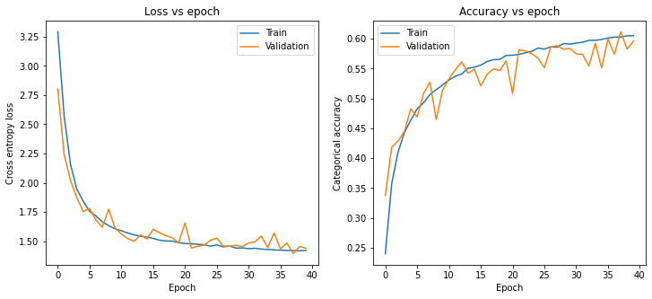

```python
plot_learning_curves()
```

Comparing $l_1$ and $l_2$, note that a crucial difference between them is that the weights using $l_1$ can actually become zero. This is not desirable, so usually, $l_2$ is preferred to $l_1$. But in out case, we see that it works much better. Perhaps it is related to the fact that for the same dataset, we had huge weights when implementing the MLP, so the penalisation procedure using the absolute value rather than the square of the weights gives us a better regularisation effect with this coefficient. Moreover, it may be related to the fact that our data is not sparse and some of the weights being reduced to zero in the $l_1$ case is more effective than having them shrink down but never become 0 as is the case in $l_2$.

#### L1 L2 regularisation

```python
def get_model_l1l2(regul_coeff):
    model = Sequential([
        # layer with filters (the number of output filters in the convolution),
        # kernel width (height and width of the 2D convolution window) (3x3)

        Conv2D(32, (3, 3), activation='relu', input_shape=(32,32,3), kernel_regularizer=l1_l2(regul_coeff,regul_coeff)),  # 3x3 feature maps
        MaxPooling2D(pool_size=(2,2)),  # 2x2 maximum pooling layers

        Conv2D(64, (3, 3), activation='relu', kernel_regularizer=l1_l2(regul_coeff, regul_coeff)),  # 3x3 feature maps
        MaxPooling2D(pool_size=(2,2)),  # 2x2 maximum pooling layers

        Conv2D(64, (3, 3), activation='relu', kernel_regularizer=l1_l2(regul_coeff,regul_coeff)),  # 3x3 feature maps

        Dense(64, activation='relu', kernel_regularizer=l1_l2(regul_coeff,regul_coeff)),

        Flatten(),
        Dense(10, kernel_regularizer=l1_l2(regul_coeff,regul_coeff), activation='softmax')  # 10 outputs, softmax activation
    ])
    model.compile(loss='categorical_crossentropy', optimizer=sgd, metrics=['accuracy'])
    return model
```

```python
model_l1l2 = get_model_l1regul(regul_coeff=0.0005)
model_l1l2.summary()
```

```
Model: "sequential_11"
_________________________________________________________________
Layer (type)                 Output Shape              Param #
=================================================================
conv2d_36 (Conv2D)           (None, 30, 30, 32)        896
_________________________________________________________________
max_pooling2d_27 (MaxPooling (None, 15, 15, 32)        0
_________________________________________________________________
conv2d_37 (Conv2D)           (None, 13, 13, 64)        18496
_________________________________________________________________
max_pooling2d_28 (MaxPooling (None, 6, 6, 64)          0
_________________________________________________________________
conv2d_38 (Conv2D)           (None, 4, 4, 64)          36928
_________________________________________________________________
dense_19 (Dense)             (None, 4, 4, 64)          4160
_________________________________________________________________
flatten_11 (Flatten)         (None, 1024)              0
_________________________________________________________________
dense_20 (Dense)             (None, 10)                10250
=================================================================
Total params: 70,730
Trainable params: 70,730
Non-trainable params: 0
_________________________________________________________________
```

```python
(x_train, y_train), (x_val, y_val) = load_data()  # load the CIFAR-10 dataset

val_data = tf.data.Dataset.from_tensor_slices((x_val.astype(np.float32), y_val.astype(np.float32)))
val_data = val_data.batch(128)
```

```python
history = model_l1l2.fit(x_train, y_train, epochs=40, verbose=1,
                       validation_data=val_data, batch_size=128)
```

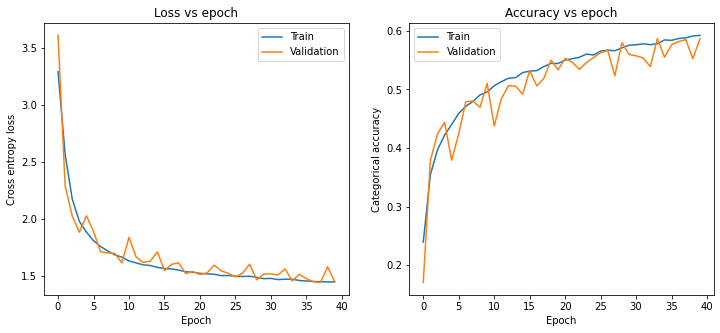

```python
plot_learning_curves()
```

#### 1.2.4. Comparison with MLP

This difference in performance is due to the fact that all layers in the MLP are fully connected whcih yields redundancy and overfitting, while the CNN with dropout takes advantage of the regularising effect of the sparsity: it decreases overfitting and significantly increases the training speed. Also, the tensorflow keras modules use much better optimised functions and methods than a model built from scratch with numpy in a few days.

Moreover, the CNN takes into account all dimensions of the input dataset, which for a coloured image are 3 (2 for pixel dimensions and 1 for the colour scheme), which is much more compared to the MLP where the input data has to be flattened to a 1-D vector: some of the important features may be lost in the flattening procedure and thus affect negatively the performance of the MLP on this dataset.

# Task 2

```python
import math
import numpy as np
import pandas as pd
import seaborn as sns
from scipy.sparse import linalg
import matplotlib.pyplot as plt
import warnings
warnings.filterwarnings('ignore')
```

In this task, we will work with the Zachary's karate club dataset. We have $N=34$ individuals and two sets of information:

- a feature matrix F, size $N \times p$, $N=34$ individuals, $p=100$ feeatures of the individual
- an adjacency matrix A, size $N \times N$, $N=34$ individuals, describing the social network with $E=78$ edges

## 2.1. Clustering of the feature matrix

We will analyse the feature matrix F using k-means clustering, which is one of the most common methods in unsupervised learning, where we have no ground truth. The goal is to find a unique membership for each sample in one of the clusters, which is defined as an assignment matrix $H$ of 1s and 0s. It is of size $N \times k$, and its entry $H_{nk}=1$ if sample (individual in our case) $n$, $n=1,...,N$ is in cluster $k$, and 0 otherwise.

```python
# import the feature matrix as numpy array
F = np.loadtxt(open("feature_matrix_karate_club.csv", "rb"), delimiter=",", skiprows=1)  # feature matrix
print('shape of F with indices',F.shape)
print(F[:,0])
F = F[:,1:]  # clean the matrix F from the first column of indices:
print(np.round(F[:,0],2))
print('shape of cleaned F',F.shape)
print(np.round(F,2))
```

```
shape of F with indices (34, 101)
[ 0.  1.  2.  3.  4.  5.  6.  7.  8.  9. 10. 11. 12. 13. 14. 15. 16. 17.
 18. 19. 20. 21. 22. 23. 24. 25. 26. 27. 28. 29. 30. 31. 32. 33.]
[ 0.15  0.21  0.09  0.21  0.05  0.08  0.15  0.2   0.11 -0.01  0.02  0.04
  0.09  0.14  0.11  0.2   0.04  0.04  0.01  0.03  0.21  0.05 -0.11  0.12
  0.16  0.14  0.09  0.12  0.11  0.    0.06  0.07  0.16 -0.  ]
shape of cleaned F (34, 100)
[[ 0.15 -0.19 -0.11 ...  0.02 -0.02  0.09]
 [ 0.21 -0.02 -0.09 ... -0.03 -0.15 -0.03]
 [ 0.09 -0.26 -0.03 ... -0.09 -0.02  0.17]
 ...
 [ 0.07  0.02 -0.03 ...  0.08 -0.14 -0.03]
 [ 0.16 -0.13 -0.14 ...  0.01  0.1   0.15]
 [-0.   -0.11 -0.1  ...  0.05 -0.15  0.02]]
```

```
number of samples N = 34
number of features p = 100
```

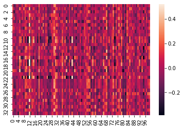

```python
hm = sns.heatmap(F)  # dear heatmap to analyse correlations/symmetry

n_samples, n_features = F.shape # get N and p
print('number of samples N =',n_samples)
print('number of features p =',n_features)
```

We check that there is no significant corelation structure in the feature matrix.

Implementation of the k-means algorithm:

Note the results are highly sensitive to the random seed due to the relatively low number of samples compared to features - the labels randomly assigned to the 34 data points in some initialisations do not cover all labels (one is missing, for example). This creates a problem with centroid assignment - in that case we assign a random data point to be the centroid for that label. This is quite hacky and less than ideal, something that happens and must be dealt with when working with a dataset with few samples but many fatures. Note this is not the only approach one could take to solve this, we could also initialise a random vector with random entries, but this is likely not better as it could create inconsistencies in the in-between distance calculation.

```python
# two methods to generate the labels: (both still produce some samples with missing range)
k=9
old_list = np.arange(k)
new_list = []
for x in range(n_samples):
    new_list.append(np.random.choice(old_list))
print(np.array(new_list))
print(np.unique(np.array(new_list)))

labels = np.random.randint(low=0, high=k, size=n_samples)
print(labels)
print(np.unique(labels))
```

```
[6 3 7 1 8 5 8 4 5 1 7 3 2 8 0 6 1 3 6 1 5 0 2 0 5 8 4 7 4 7 5 0 0 7]
[0 1 2 3 4 5 6 7 8]
[7 5 3 7 5 4 5 7 5 8 0 3 1 1 4 3 7 3 3 6 4 0 5 6 0 0 2 2 1 3 0 0 0 4]
[0 1 2 3 4 5 6 7 8]
```

```python
# define the k-means algorithm

def clustering_2(F, k, max_iter, difference, n_inits):
    # set seed for reproducible results
    np.random.seed(107)

    d_within_list = []
    d_between_list = []
    difference_list = []

    # create labels matrix
    labels_matrix = np.zeros((100,34))

    for j in range(n_inits):
        # randomly generate the labels - note there are inits when there are no data points assigned to a label
        # this case breaks the algorithm at centroid assignment - see hack below to avoid this
        labels = np.random.randint(low=0, high=k, size=n_samples)
#         print('unique labels',np.unique(labels))  # uncomment and run to see the phenomenon described above
        F_labels = np.append(F, labels.reshape(-1,1), axis=1)  # append the random labels to the matrix F
        centroids = np.zeros((k, n_features))

        # for this random initialisation of labels, collect distances for each k
        for i in range(k):
            centr=[]
            for x in F_labels:
                if x[-1]==i:  # if it corresponds to the label that we iterate over the k's
                    centr.append(x)  # append to the centroid list (data points with label i)
            if len(centr)==0:  # check the case if none of the 34 data points have that label
                rand_x = np.random.randint(low=0, high=n_samples)  # choose a random number between 0 and 33
                centroids[i] = F_labels[rand_x,:-1]  # assign this random data point to be the centroid
            else:
                # centroid at each cluster - mean of data points with label i
                centroids[i] = np.mean(centr, axis=0)[:-1]

        # K-MEANS ALGORITHM: iterate over any number of iterations: relabel data points to the closest centroid
        new_labels = np.zeros(len(F))
        for i in range(max_iter):
            distances = np.array([np.linalg.norm(F - c, axis=1) for c in centroids])  # dist between data points and centroids
            new_labels = np.argmin(distances, axis=0)  # new_labels: computed by finding centroid with minimal distance

            if (labels==new_labels).all():  # labels unchanged
                labels = new_labels
                break
            else:  # labels changed
                difference = np.mean(labels!=new_labels)  # difference: percentage of changed labels
                labels = new_labels
                for c in range(k):
                    # update centroids by taking the mean over associated data points
                    if (labels == c).any():
                        centroids[c] = np.mean(F[labels==c], axis=0)  # take mean of data points

        labels_matrix[j,:] = labels

        # append the new labels to F
        F_new_labels = np.append(F, labels.reshape(-1,1), axis=1)

        # compute the within distance
        distance_within = 0
        for i in range(k):  # in the cluster
            for x in F_new_labels:  # take each point within the cluster
                if x[-1]==i:  # if it is in the cluster, measure its distance to the centroid of that cluster
                    distance_within += np.linalg.norm(x[:-1]-centroids[i])

            # done iterating through cluster data pts, iterate through the next cluster, add to the same d_w
        d_within_list.append(distance_within)  # append the W(C) distance for this random init

        # compute the between distance
        distance_between = 0
        for x in F:
            for y in F:
                distance_between += np.linalg.norm(x-y)
        d_between_list.append(distance_between/2)  # divide by 2 to get individual pairs


    difference_list.append(difference)

    WC = np.mean(d_within_list)/2  # get the avg W(C) for this k over the random inits
    BC = np.mean(d_between_list) - WC
    difference = sum(difference_list)/len(difference_list)

    return labels, WC, BC, difference, labels_matrix
```

```python
# set parameters
max_iter = 100
difference = 0
n_inits = 100

labels = []
within_distances = []
between_distances = []
label_change = []
for k in range(2,11):
    print('k =',k)
    label, WC, BC, difference, _ = clustering_2(F, k, max_iter, difference, n_inits)
    print('W(C) =', WC)
    print('B(C) =', BC)
    print('% of changed labels', 100*difference)
    within_distances.append(WC)
    between_distances.append(BC)
    labels.append(label)
    label_change.append(100*difference)
```

```
k = 2
W(C) = 13.03445990773608
B(C) = 758.1330236987006
% of changed labels 47.05882352941176
k = 3
W(C) = 11.76697384000838
B(C) = 759.4005097664283
% of changed labels 2.941176470588235
k = 4
W(C) = 10.846802557733017
B(C) = 760.3206810487037
% of changed labels 5.88235294117647
k = 5
W(C) = 10.223661115526655
B(C) = 760.9438224909101
% of changed labels 2.941176470588235
k = 6
W(C) = 9.7936256982184
B(C) = 761.3738579082183
% of changed labels 8.823529411764707
k = 7
W(C) = 9.395792778210476
B(C) = 761.7716908282263
% of changed labels 5.88235294117647
k = 8
W(C) = 9.081202915798377
B(C) = 762.0862806906383
% of changed labels 5.88235294117647
k = 9
W(C) = 8.776627411974939
B(C) = 762.3908561944618
% of changed labels 2.941176470588235
k = 10
W(C) = 8.521295271581216
B(C) = 762.6461883348554
% of changed labels 2.941176470588235
```

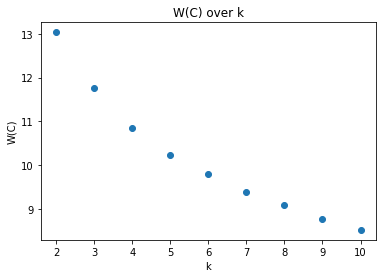

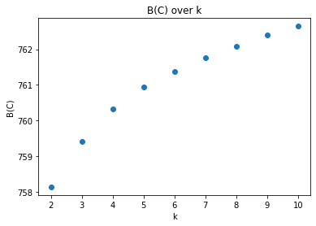

```python
# plot the within and in-between distances

plt.scatter(np.arange(2,11),within_distances)
plt.title("W(C) over k")
plt.xlabel("k")
plt.ylabel("W(C)")
plt.show()

plt.scatter(np.arange(2,11),between_distances)
plt.title("B(C) over k")
plt.xlabel("k")
plt.ylabel("B(C)")
plt.show()

plt.show()
```

We can see that as expected, the within-cluster distance is decreasing as we increase the number of clusters, and the in-between cluster distance increases with k.

It is not entirely clear whether the elbow method is helpful here as there is no clearly identifiable 'elbow', a potential one could be around k=4.

### 2.1.2.

We will now evaluate the optimal clustering according to the Calinski-Harabasz (CH) score. It is the ratio of the dispersion beetween the clusters and dispersion inside the cluster for all clusters, so the higher it is, the better the performance of the clustering algorithm. We will choose the optimal clustering $k$ where the CH score is the highest.

For k clusters and N data points (34 in our case), the score is

$$ I = \frac{N-k}{k-1} \times \frac{B(C)}{W(C)}, $$

where $W(C)$ is the within-cluster dispersion, and $B(C)$ is the in-between cluster dispersion.

There are two equivalent ways to calculate W(C): measuring distances between the individual data points in the clusters (as we did in the implmentation above), or measure the distance betweeen the centroid of the cluster in question and the other data points (for within - data points in that cluster, for between - data points in other clusters).

These measures are calculated in the $l_2$ norm (Euclidean distance, we use np.linalg.norm()): $$ W(C) = \frac{1}{2} \sum_i^k \sum_{x \in C_i} \| x - c_i \|^2, $$ $$ B(C) = \frac{1}{2} \sum_{i=1}^N \sum_{j=1}^N \| x_i - x_j \|^2 - W(C) $$ where $c_i$ is the centroid of cluster i, $C_i$ is the cluster $i$ of a specific clustering and $x$ are the data points in that cluster.

Sources:

- Calinski, T. and Harabasz, J. (1974) A Dendrite Method for Cluster Analysis: Communications in Statistics. Theory and Methods, 3, 1-27, DOI: http://dx.doi.org/10.1080/03610927408827101
- "Clustering Indices" by Bernard Desgraupes, University Paris Ouest, Lab Modal’X, November 2017. URL: https://cran.r-project.org/web/packages/clusterCrit/vignettes/clusterCrit.pdf
- "CalinskiHarabaszEvaluation", MATLAB documentation https://uk.mathworks.com/help/stats/clustering.evaluation.calinskiharabaszevaluation-class.html
- Documentation for R code tutorial http://ethen8181.github.io/machine-learning/clustering_old/clustering/clustering.html

```python
def CH_score(k_range, WC, BC, F):
    assert(len(k_range)==len(WC))
    assert(len(k_range)==len(BC))

    N = F.shape[0] # number of individuals
    scores = []
    for i in range(len(k_range)):
        score = (BC[i]/WC[i])*(N-k_range[i])/(k_range[i]-1)
        scores.append(score)
    return scores
```

```python
k_range = np.arange(2,11)  # initialise range of candidate k's
CH = CH_score(k_range, within_distances, between_distances, F) # compute the CH score
```

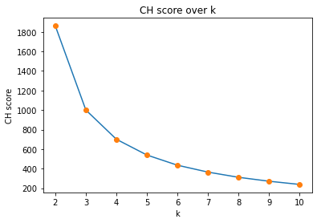

```python
# plot the CH score
plt.plot(np.arange(2,11),CH)
plt.plot(np.arange(2,11),CH,'o')
plt.title("CH score over k")
plt.xlabel("k")
plt.ylabel("CH score")
plt.show()
```

The CH score is the highest for the optimal k, therefore we can safely say looking at the graph that the k-means algorithm suggests that the optimal number of clusters is k=2.

### 2.1.3

[output not shown]

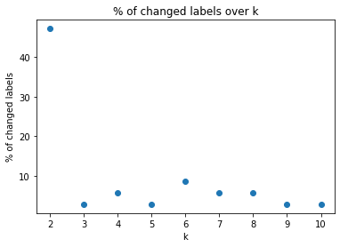

```python
# plot the % of labels changed
print('percentage of changed labels from previous iteration',label_change)

plt.scatter(np.arange(2,11),[x for x in label_change])
plt.title("% of changed labels over k")
plt.xlabel("k")
plt.ylabel("% of changed labels")
plt.show()
```

An additional metric is to check the labels in each of the 100 initialisations explicitly, by storing them in a matrix and calculating the number when the labels are equal. Of course, a problem with such an approach is that for instance for k=2, we can have the same clustering, but for one initialisation the cluster has label 0 and for another it has label 1.

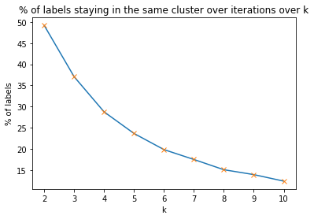

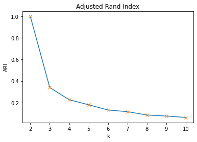

```python
klist = []
ari_list = []
for k in range(2,11):
    _, _, _, _, labels_matrix = clustering_2(F, k, max_iter, difference, n_inits)
    no = 0
    n = 34
    n_ari = 0
    for i in range(n):  # iterate through all 34 members
        for j in range(i+1,n):
            # count the number of the same labels
            no += np.sum(labels_matrix[:,i]==labels_matrix[:,j])
            n_ari += ARI(labels_matrix[:,i],labels_matrix[:,j])
    no_pairs = n*(n-1)/2  # number of pairs
    klist.append(no/no_pairs)
    ari_list.append(n_ari/no_pairs)

plt.plot(np.arange(2,11),klist)
plt.plot(np.arange(2,11),klist,'x')
plt.title('% of labels staying in the same cluster over iterations over k')
plt.ylabel('% of labels')
plt.xlabel('k')
plt.show()

plt.plot(np.arange(2,11),ari_list)
plt.plot(np.arange(2,11),ari_list,'x')
plt.title('Adjusted Rand Index')
plt.ylabel('ARI')
plt.xlabel('k')
plt.show()
```

```python
print('at k=2: ',klist[0]*2,'%')
```

```
at k=2:  98.39572192513369 %
```

Unsurprisingly, given that these metrics are quite similar, we see that the percentage of the labels staying in the same cluster is the largest for k=2. Note that the 50% result for k=2 is due to the labeling differences which could label the samee clusters as having 0 or 1 at different iterations - merely multiplying it by 2 gives us a high measure of robustness of the clustering in k=2: around 98.4%.

We also use the Adjusted Rand Index to show that the quality of the clusterings, even adjusted to chance, is the best for k=2 (the functions are in task 2.3).

### 2.2. Dimensionality reduction of the feature matrix

#### 2.2.1.

```python
F = np.loadtxt(open("feature_matrix_karate_club.csv", "rb"), delimiter=",", skiprows=1)  # feature matri
F = F[:,1:] # eliminate the indices
print(F.shape)
print(np.round(F,2))
```

```
(34, 100)
[[ 0.15 -0.19 -0.11 ...  0.02 -0.02  0.09]
 [ 0.21 -0.02 -0.09 ... -0.03 -0.15 -0.03]
 [ 0.09 -0.26 -0.03 ... -0.09 -0.02  0.17]
 ...
 [ 0.07  0.02 -0.03 ...  0.08 -0.14 -0.03]
 [ 0.16 -0.13 -0.14 ...  0.01  0.1   0.15]
 [-0.   -0.11 -0.1  ...  0.05 -0.15  0.02]]
```

```python
# implement PCA algorithm
def pca_function(X,k):
    C = 1.0/(len(X)-1) * np.dot(X.T, X)  # covariancee matrix
    # compute eigenvalues and eigenvectors using the eigsh scipy function

    eigenvalues, eigenvectors = linalg.eigsh(C, k, which="LM", return_eigenvectors=True)

    # NumPy alternative, but easier to use SciPy
#     eigenvalues, eigenvectors = np.linalg.eig(C)

    # sort them from largest to smallest
    sorted_index = np.argsort(eigenvalues)[::-1]
    eigenvalues=eigenvalues[sorted_index]
    eigenvectors=eigenvectors[:,sorted_index]

#     eigenvalues=eigenvalues[sorted_index][:k] # to be used with NumPy alternative
#     eigenvectors=eigenvectors[:,sorted_index][:,:k]

    X_pca = X.dot(eigenvectors)  # transform our data
    # scipy eigsh returns these sliced already, but we are only allowed to use numpy
    return X_pca, eigenvectors, eigenvalues
```

###### 1D PCA

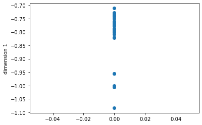

```python
# compute the projection, the eigenvector and eigenvalues from our function
k=1
F_pca, eigenvectors, eigenvalues = pca_function(F,k)
plt.plot(np.zeros(F_pca.shape[0]),F_pca[:,0],'o')
plt.ylabel('dimension 1')
plt.show()
```

```python
explained_variances = (eigenvalues / eigenvalues.sum())
print('The explained variance for the first principle component is: {}'.format(explained_variances))
```

```
The explained variance for the first principle component is: [1.]
```

We can notice that the data is separable in two clusters - one largee and one small, but baseed on the knowleedge about the dataset and best practice we clearly need to increase the dimensions to further investigate the structure of the data.

###### 2D PCA

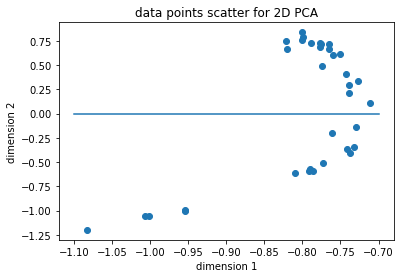

```
The explained variance for the two principle components is: [0.59480515 0.40519485]
```

```python
k=2
F_pca2, eigenvectors2, eigenvalues2 = pca_function(F,k)
plt.scatter(F_pca2[:,0],F_pca2[:,1])
plt.title('data points scatter for 2D PCA')
plt.plot([-1.1,-0.9,-0.7],[0,0,0])
plt.xlabel('dimension 1')
plt.ylabel('dimension 2')
plt.show()
explained_variances2 = (eigenvalues2 / eigenvalues2.sum())
print('The explained variance for the two principle components is: {}'.format(explained_variances2))
```

We notice that the clustering strucure is emerging from the increased dimension - there is a clear split between the data ay y=0, separating it in two clusters. Although it is quite obvious already, it would be useful to increase the dimension. Also, we can see from the explained variance that the second dimension does carry significant information - we should only start disregarding the dimensions with small explained variance, 40% is far from being small. Next, we check the third dimension.

###### 3D PCA

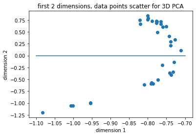

```
The explained variance for the first three principle components is: [0.53203868 0.3624369  0.10552442]
```

```python
k=3
F_pca3, eigenvectors3, eigenvalues3 = pca_function(F,k)
plt.scatter(F_pca3[:,0],F_pca3[:,1])
plt.plot([-1.1,-0.9,-0.7],[0,0,0])
plt.title('first 2 dimensions, data points scatter for 3D PCA')
plt.xlabel('dimension 1')
plt.ylabel('dimension 2')
plt.show()
explained_variances3 = (eigenvalues3 / eigenvalues3.sum())
print('The explained variance for the first three principle components is: {}'.format(explained_variances3))
```

We check that indeed the scatter plot for the first two dimensions in the 3D PCA corresponds to the one for 2D PCA.

As for the explained variance, the difference here is that as we will see below we can gather more information from the third dimension, which carries 10.5% of the variance - it is less significant than the first two: we will see whether it reveals anything important in the 3D scatter plot.

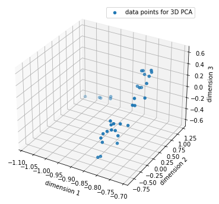

```python
plt.figure(figsize=(9,6))
ax = plt.axes(projection='3d')
ax.scatter3D(F_pca3[:,0],F_pca3[:,1],F_pca3[:,2], label='data points for 3D PCA')
ax.legend()
ax.set_xlabel('dimension 1')
ax.set_ylabel('dimension 2')
ax.set_zlabel('dimension 3')
plt.show()
```

There seem to be more pronounced clusters forming - the introduction of the third dimension was useful: there seems to be a clearly separable cluster forming from the larger cluster of points seen in the 2D plot, which consists of the points separated at y=0 (zero hyperplane in dimension 2). The smaller number of points that were clearly separable in the lower dimensions are still separated - it is even more obvious.

###### Comparison to clustering results in 2.1.:

In 2.1., we got the optimal number of clusters to be 2, and the PCA results above show that indeed a separation into two clusters of similar sizes is possible.

Moreover, due to its global approach, the k-means algorithm does not pick up on the small number of points further away, which would make the optimal number of clusters 3. We will see later that other clustering approaches do pick up on the smaller clusters friendship groups forming $\textbf{within}$ the two main clusters (karate clubs).

#### 2.2.2.

```python
# plot the explained variances on y-log scale:
k_array = np.arange(1,11)

F_pca_arr = []
eigenvectors_arr = []
eigenvalues_arr = []
explained_variances_arr = []
for k in k_array:
    F_pca, eigenvectors, eigenvalues = pca_function(F,k)
    F_pca_arr.append(F_pca)
    eigenvectors_arr.append(eigenvectors)
    eigenvalues_arr.append(eigenvalues)
    explained_variances_arr.append(eigenvalues / eigenvalues.sum())
```

We also do a log plot to more clearly see the variance distribution differences for the higher dimensions.

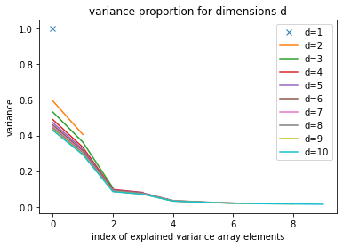

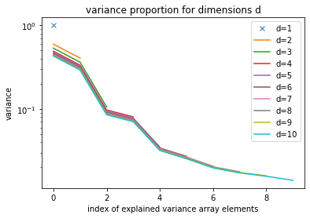

```python
plt.plot(0,explained_variances_arr[0],'x',label='d=1')
for i in range(1,len(k_array)):
    plt.plot(explained_variances_arr[i],label='d='+str(i+1))
plt.xlabel('index of explained variance array elements')
plt.ylabel('variance')
plt.title('variance proportion for dimensions d')
plt.legend()
plt.show()

plt.plot(0,explained_variances_arr[0],'x',label='d=1')
for i in range(1,len(k_array)):
    plt.yscale('log')
    plt.plot(explained_variances_arr[i],label='d='+str(i+1))
plt.xlabel('index of explained variance array elements')
plt.ylabel('variance')
plt.title('variance proportion for dimensions d')
plt.legend()
plt.show()
```

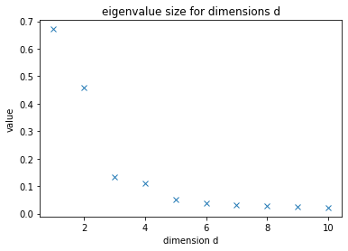

```python
plt.plot(np.arange(1,11),eigenvalues,'x')
plt.xlabel('dimension d')
plt.ylabel('value')
plt.title('eigenvalue size for dimensions d')
plt.show()
```

We can see that the porportion of the information contained in the last components after around dimension d = 2 is very small, both from the magnitudes of the explained variance (eigenvectors) and the eigenvalue size where we see a sharp drop in the size for d = 2 onwards. In other words, the above spectral decomposition shows that the variance of the components becomes marginally important after dimension d = 2, and the optimal dimension to choose is d=2.

Interestingly, the amount of information contained in the dimensions 3 and 4 correspond to the results by the Louvain algorithm which is a bottom-up approcah using modularity optimisation - it starts from individual nodes and picks up on the individual friendship groups that have formed within the two karate club groups, with the optimal number of clusters being 4. This explains why the explained variance of 3 and 4 is higher than the remaining ones.

### 2.3. Graph-based analysis

Analysis of the friendship graph characterised by the adjacency matrix A.

```python
import networkx as nx
from scipy.sparse import csc_matrix
```

```python
# load the adjacency matrix
A = np.loadtxt(open("karate_club_graph.csv", "rb"), delimiter=",", skiprows=1)  # adjacency matrix
print('shapee of A with indices',A.shape)
print(np.round(A,3))
print(A[:,0])
A = A[:,1:] # remove the indices from the first column
print(A[:,0])
print('shape of cleaned A',A.shape)
```

```
shapee of A with indices (34, 35)
[[ 0.  0.  1. ...  1.  0.  0.]
 [ 1.  1.  0. ...  0.  0.  0.]
 [ 2.  1.  1. ...  0.  1.  0.]
 ...
 [31.  1.  0. ...  0.  1.  1.]
 [32.  0.  0. ...  1.  0.  1.]
 [33.  0.  0. ...  1.  1.  0.]]
[ 0.  1.  2.  3.  4.  5.  6.  7.  8.  9. 10. 11. 12. 13. 14. 15. 16. 17.
 18. 19. 20. 21. 22. 23. 24. 25. 26. 27. 28. 29. 30. 31. 32. 33.]
[0. 1. 1. 1. 1. 1. 1. 1. 1. 0. 1. 1. 1. 1. 0. 0. 0. 1. 0. 1. 0. 1. 0. 0.
 0. 0. 0. 0. 0. 0. 0. 1. 0. 0.]
shape of cleaned A (34, 34)
```

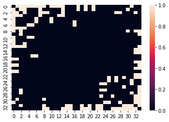

```python
hmA = sns.heatmap(A)
```

Notice that most of the entries are 0 - this is a highly sparse network. Also, the nodes with the most connections seem to be concentrated around the first few and last few indices such as 0,1,2,31,32,33. We will check this assertion by calculating three different centrality measures.

```python
print('zero entries',np.count_nonzero(A==0))
print('one entries',np.count_nonzero(A==1))
print('% of connections',np.count_nonzero(A==0)/np.count_nonzero(A==1))
print('total entries',34**2)
```

```
zero entries 1000
one entries 156
% of connections 6.410256410256411
total entries 1156
```

Degree centrality is a ranking based on the importance of nodes. We will show three different kinds of centrality:

- PageRank
- degree centrality
- eigenvector centrality

##### PageRank

Conceived for a directed graph (websites for nodes, directed links for edges).

"assign higher centrality to nodes where many searches will reside with higher probability, where the centrality of the nodes of those incoming edges also plays a role, i.e., being pointed at from an important node increases your score."

We have the equation for the stationary eigenvector $\textbf{c}_{pr}$ of the Markov matrix $M = AD^{-1}$ with parameter $\alpha = 0.85$: $$ (I - \alpha M)\textbf{c}_{pr} = (1-\alpha)\frac{\textbf{1}}{N}, $$ where $N$ is the size of $A$ (number of nodes in the network).

```python
# solving using the formula given in lectures
def pagerank_linear_solution(A,alpha=0.85):
    n = A.shape[0]  # number of nodes
    D = np.diag(np.sum(A, axis=1))
    M = np.dot(A,np.linalg.inv(D))  # get Markov matrix
    c = np.linalg.solve((np.identity(n)-alpha*M), np.ones(n)*(1-alpha)/n)
    return c

# iterative algorithm
def pagerank_iter(A, n_its, alpha=0.85):
    n = A.shape[0]
    v = np.random.rand(n, 1)  # randomly initialise a vector
    v = v / np.linalg.norm(v, 1)
    A_hat = (alpha * A + (1-alpha)/n)
    for i in range(n_its):
        v = A_hat @ v  # iterative step
    return v/np.sum(v)
```

```python
p_rank = pagerank_linear_solution(A, alpha=0.85) # set parameter to default value
print(p_rank.T)
```

```
[0.09699729 0.05287692 0.05707851 0.03585986 0.02197795 0.02911115
 0.02911115 0.0244905  0.02976606 0.0143094  0.02197795 0.00956475
 0.01464489 0.02953646 0.01453599 0.01453599 0.01678401 0.01455868
 0.01453599 0.01960464 0.01453599 0.01455868 0.01453599 0.03152251
 0.02107603 0.0210062  0.01504404 0.02563977 0.01957346 0.02628854
 0.02459016 0.03715809 0.07169323 0.10091918]
```

```python
n_its = 200
la = pagerank_iter(A, n_its, alpha=0.85)
print('centralities from iterative calculation:\n',la.T)
```

```
centralities from iterative calculation:
 [[0.07070836 0.05268054 0.06265366 0.04190229 0.01580078 0.01661848
  0.01661848 0.03400838 0.04503567 0.02071267 0.01580078 0.01107165
  0.01718411 0.04482437 0.02051035 0.02051035 0.00560554 0.01875637
  0.02051035 0.02957237 0.02051035 0.01875637 0.02051035 0.03022223
  0.01208261 0.01250759 0.01553881 0.02688385 0.02629195 0.0271857
  0.03476461 0.03824725 0.06126671 0.07414608]]
```

```python
# not used anywhere in this task, shown for demonstrative purposes
g = nx.Graph(A) # networkx graph
print('degrees',g.degree())
Al = csc_matrix(g,dtype=np.float)
print(Al.shape)

a = nx.pagerank(g)
print('pagerank centralities, nx',a)
```

```
degrees [(0, 16), (1, 9), (2, 10), (3, 6), (4, 3), (5, 4), (6, 4), (7, 4), (8, 5), (9, 2), (10, 3), (11, 1), (12, 2), (13, 5), (14, 2), (15, 2), (16, 2), (17, 2), (18, 2), (19, 3), (20, 2), (21, 2), (22, 2), (23, 5), (24, 3), (25, 3), (26, 2), (27, 4), (28, 3), (29, 4), (30, 4), (31, 6), (32, 12), (…
(1, 34)
pagerank centralities, nx {0: 0.09700181758983709, 1: 0.05287839103742701, 2: 0.057078423047636745, 3: 0.03586064322306479, 4: 0.021979406974834498, 5: 0.02911334166344221, 6: 0.02911334166344221, 7: 0.024490758039509182, 8: 0.029765339186167028, 9: 0.014308950284462801, 10: 0.021979406974834498, 11…
```

```python
# define function to output the top 8 values and corresponding indices
def top_8(centrality_arr):
    ind = np.arange(34)
    m = np.zeros((34,2))
    m[:,0] = ind
    m[:,1] = centrality_arr.reshape(34,)
    sorted_m = m[np.argsort(m[:, 1])]
    top_values = sorted_m[-8:,1]
    top_indices = sorted_m[-8:,0]
    return top_values, top_indices

top_values_pagerank, top_indices_pagerank = top_8(p_rank)
print('top values, descending order', top_values_pagerank[::-1])
print('top node indices, descending order', top_indices_pagerank[::-1])
```

```
top values, descending order [0.10091918 0.09699729 0.07169323 0.05707851 0.05287692 0.03715809
 0.03585986 0.03152251]
top node indices, descending order [33.  0. 32.  2.  1. 31.  3. 23.]
```

##### Degree centrality

Here we will take the centrality measure of a node to be simply the its degree:

```python
degree_centr = np.diag(np.sum(A, axis=1))
print('list of degrees of each node:',np.diag(degree_centr))
top_values_degree, top_indices_degree = top_8(np.diag(degree_centr))
print('top values, descending order', top_values_degree[::-1])
print('top node indices, desceending order', top_indices_degree[::-1])
```

```
list of degrees of each node: [16.  9. 10.  6.  3.  4.  4.  4.  5.  2.  3.  1.  2.  5.  2.  2.  2.  2.
  2.  3.  2.  2.  2.  5.  3.  3.  2.  4.  3.  4.  4.  6. 12. 17.]
top values, descending order [17. 16. 12. 10.  9.  6.  6.  5.]
top node indices, desceending order [33.  0. 32.  2.  1. 31.  3. 23.]
```

##### Eigenvector centrality

This centrality places the importance of the nodes based on their corresponding eigenvector.

```python
# compute the eigenvector associated with the largest eigenvalue
eigenvalue, eigenvector = linalg.eigsh(A, 1, which="LM", return_eigenvectors=True)
print(np.round(eigenvector,3).T) # print the eigenvectors with unchanged indices

top_values_eig, top_indices_eig = top_8(eigenvector)
print('top values, descending order', top_values_eig[::-1])
print('top node indices, descending order', top_indices_eig[::-1])
```

```
[[0.355 0.266 0.317 0.211 0.076 0.079 0.079 0.171 0.227 0.103 0.076 0.053
  0.084 0.226 0.101 0.101 0.024 0.092 0.101 0.148 0.101 0.092 0.101 0.15
  0.057 0.059 0.076 0.133 0.131 0.135 0.175 0.191 0.309 0.373]]
top values, descending order [0.37336347 0.35549144 0.3171925  0.30864422 0.26595992 0.22740391
 0.22647272 0.21117972]
top node indices, descending order [33.  0.  2. 32.  1.  8. 13.  3.]
```

```python
# comparison of results
print('pagerank central. max indices',top_indices_pagerank[::-1])
print('degree centrality max indices',top_indices_degree[::-1])
print('eigenvectors cen. max indices',top_indices_eig[::-1])
```

```
pagerank central. max indices [33.  0. 32.  2.  1. 31.  3. 23.]
degree centrality max indices [33.  0. 32.  2.  1. 31.  3. 23.]
eigenvectors cen. max indices [33.  0.  2. 32.  1.  8. 13.  3.]
```

We clearly have two main nodes - the first (index 0) and last one (index 33), each corresponding to Mr.Hi and Officer. Then, we have some leading nodes, notably 32, 2 and 1, that appear in all three centrality measures.

Pagerank is a variant of the eigenvector centrality algorithm but has a different result than the eigenvector centrality. This is because we use the degree matrix $D$ in calculating the Markov matrix $M = AD^{-1}.$

Investigate the correlation between the three centralities:

```python
def top_ind(centrality_arr):
    ind = np.arange(34)
    m = np.zeros((34,2))
    m[:,0] = ind
    m[:,1] = centrality_arr.reshape(34,)
    sorted_m = m[np.argsort(m[:, 1])]
    top_values = sorted_m[:,1]
    top_indices = sorted_m[:,0]
    return top_values[::-1], top_indices[::-1]  # descending order
```

```python
values_pr_all, indices_pr_all = top_ind(p_rank)  # pagerank centrality
values_deg_all, indices_deg_all = top_ind(np.diag(degree_centr))  # degree centrality
values_eig_all, indices_eig_all = top_ind(eigenvector)  # eigenvector centrality
```

```python
# Pearson correlation
c1 = np.corrcoef(indices_pr_all,indices_deg_all)  # pr and deg
c2 = np.corrcoef(indices_pr_all,indices_eig_all)  # pr and eig
c3 = np.corrcoef(indices_deg_all,indices_eig_all)  # deg and eig
```

```python
print('Highest correlation between PageRank and Degree centralities (as expected from analysis above):\n',c1)
print('Very low correlation between PageRank and Degree centralities:\n',c2)
print('Lowest correlation between Eigenvector and Degree centralities:\n',c3)
```

```
Highest correlation between PageRank and Degree centralities (as expected from analysis above):
 [[1.         0.60183346]
 [0.60183346 1.        ]]
Very low correlation between PageRank and Degree centralities:
 [[1.         0.14010695]
 [0.14010695 1.        ]]
Lowest correlation between Eigenvector and Degree centralities:
 [[1.         0.01940413]
 [0.01940413 1.        ]]
```

#### 2.3.2

```python
from networkx.algorithms.community import greedy_modularity_communities
```

```python
A = np.loadtxt(open("karate_club_graph.csv", "rb"), delimiter=",", skiprows=1)  # adjacency matrix
A = A[:,1:]
print(A.shape)
g = nx.Graph(A)
c = list(greedy_modularity_communities(g))
```

```
(34, 34)
```

```python
print('k* is',len(c))
for i in range(len(c)):
    print('set',i+1,'of nodes:',np.array(c[i]))
clust_232 = [list(x) for x in c]  # put the clusters in list
```

```
k* is 3
set 1 of nodes: frozenset({32, 33, 8, 14, 15, 18, 20, 22, 23, 24, 25, 26, 27, 28, 29, 30, 31})
set 2 of nodes: frozenset({1, 2, 3, 7, 9, 12, 13, 17, 21})
set 3 of nodes: frozenset({0, 4, 5, 6, 10, 11, 16, 19})
```

```
['yellow', 'orange', 'orange', 'orange', 'yellow', 'yellow', 'yellow', 'orange', 'red', 'orange', 'yellow', 'yellow', 'orange', 'orange', 'red', 'red', 'yellow', 'orange', 'red', 'yellow', 'red', 'orange', 'red', 'red', 'red', 'red', 'red', 'red', 'red', 'red', 'red', 'red', 'red', 'red']
```

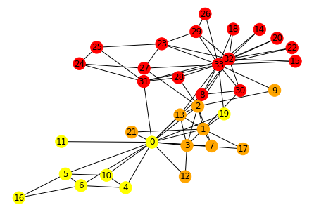

```python
# assign colours to cluster labels
colors = []
for n in g.nodes:
    if n in clust_232[0]:
        colors.append('red')
    if n in clust_232[1]:
        colors.append('orange')
    if n in clust_232[2]:
        colors.append('yellow')
print(colors)
nx.draw(g, with_labels=True, node_size=300, node_color=colors)
```

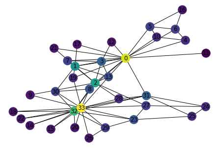

```python
# degree centrality
nx.draw(g,with_labels=True,node_color=np.diag(degree_centr))
```

The higher the degree value, the higher the centrality and the more yellow the node - we can vidualise the centrality strength easier.

```python
print('degree centrality max indices',top_indices_degree[::-1])
print('pagerank central. max indices',top_indices_pagerank[::-1])
```

```
degree centrality max indices [33.  0. 32.  2.  1. 31.  3. 23.]
pagerank central. max indices [33.  0. 32.  2.  1. 31.  3. 23.]
```

This is unusual as we expect two clusters based on the dataset.

##### 2.3.3

```python
F = np.loadtxt(open("feature_matrix_karate_club.csv", "rb"), delimiter=",", skiprows=1)  # feature matri
F = F[:,1:]
delim = pd.read_csv("ground_truth_karate_club.csv")  # ground truth

# convert categorical labels to numbers, Mr. Hi: 1, Officer: 0
diag_map = {'Mr. Hi': 1, 'Officer': 0}
delim['0'] = delim['0'].map(diag_map)
# delim.head(10)
delim_arr = np.array(delim)
print(delim_arr.shape)
ground_truth = delim_arr[:,1]
print('ground truth:',ground_truth)
```

```
(34, 2)
ground truth: [1 1 1 1 1 1 1 1 1 0 1 1 1 1 0 0 1 1 0 1 0 1 0 0 0 0 0 0 0 0 0 0 0 0]
```

```python
# set parameters
max_iter = 100
difference = 0
n_inits = 100
labels, _, _, _, labels_matrix = clustering_2(F, 2, max_iter, difference, n_inits)

pred_all_kmeans = labels_matrix.sum(axis=0)
print(pred_all_kmeans)

labels_pred_kmeans = np.zeros(34)
for i in range(len(pred_all_kmeans)):
    labels_pred_kmeans[i]=np.round(pred_all_kmeans[i]/100)
print('prediction labels k-means with k=2:',labels_pred_kmeans)
```

```
[42. 58. 42. 42. 58. 42. 58. 42. 58. 42. 58. 58. 58. 42. 42. 42. 42. 58.
 58. 42. 42. 58. 58. 42. 42. 42. 58. 42. 42. 58. 42. 58. 42. 58.]
prediction labels k-means with k=2: [0. 1. 0. 0. 1. 0. 1. 0. 1. 0. 1. 1. 1. 0. 0. 0. 0. 1. 1. 0. 0. 1. 1. 0.
 0. 0. 1. 0. 0. 1. 0. 1. 0. 1.]
```

```python
print('clusterings from greedy modularity communities',clust_232)
labels_pred_greedy_mod = np.zeros(34)
for i in range(3):
    for ind in clust_232[i]:
        labels_pred_greedy_mod[ind]=i
print('prediction labels greeedy modularity communities',labels_pred_greedy_mod)
```

```
clusterings from greedy modularity communities [[32, 33, 8, 14, 15, 18, 20, 22, 23, 24, 25, 26, 27, 28, 29, 30, 31], [1, 2, 3, 7, 9, 12, 13, 17, 21], [0, 4, 5, 6, 10, 11, 16, 19]]
prediction labels greeedy modularity communities [2. 1. 1. 1. 2. 2. 2. 1. 0. 1. 2. 2. 1. 1. 0. 0. 2. 1. 0. 2. 0. 1. 0. 0.
 0. 0. 0. 0. 0. 0. 0. 0. 0. 0.]
```

##### We now compute the Adjusted Rand Index, which is the Rand Index, only adjusted for chance.

```python
# define the contingency matrix function
def contingency_mat(y1, y2):
    # number of clusters in each
    clust_y1 = np.unique(y1).astype(int)
    clust_y2 = np.unique(y2).astype(int)
    if len(clust_y1)>len(clust_y2):
        CM = np.zeros((len(clust_y1), len(clust_y1))).astype(int)
    else:
        CM = np.zeros((len(clust_y2), len(clust_y2))).astype(int)
    for no in clust_y1:  # fill diagonal
        for nb in clust_y2:
            sum1 = 0
            for i in range(len(y1)):
                if y1[i]==no and y2[i]==nb:
                    sum1+=1
            CM[no,nb] = sum1
    return np.array(CM)
```

```python
from scipy.special import comb

# define the function to compute the ARI index
def ARI(y1, y2):
    CM = contingency_mat(y1, y2) # get the contingency matrix
    ind = 0
    sum_a = 0
    sum_b = 0
    n = sum([ sum(row) for row in CM ])  # sum all elements counted
    for i in range(CM.shape[0]):
        b_row = 0 # column sums
        for j in range(CM.shape[1]):
            b_row += CM[j,i]
            ind += comb(CM[i,j],2)
        sum_a += comb(sum(CM[i]),2)
        sum_b += comb(b_row,2)

    exp_ind = (sum_a*sum_b)/comb(n,2)
    max_index = (sum_a+sum_b)/2

    return (ind-exp_ind)/(max_index-exp_ind)
```

```python
# prin out the results
CM1 = contingency_mat(labels_pred_kmeans, labels_pred_greedy_mod)
ari1 = ARI(labels_pred_kmeans, labels_pred_greedy_mod)
print('ARI index kmeans/greedy modularity',ari1)
print('contingency matrix:\n',CM1)

CM = contingency_mat(ground_truth, labels_pred_kmeans)
ari = ARI(ground_truth, labels_pred_kmeans)
print('\nARI index ground truth/k-means',ari)
print('contingency matrix:\n',CM)

CM2 = contingency_mat(ground_truth, labels_pred_greedy_mod)
ari2 = ARI(ground_truth, labels_pred_greedy_mod)
print('\nARI index ground truth/greedy modularity',ari2)
print('contingency matrix:\n',CM2)
```

```
ARI index kmeans/greedy modularity -0.031487014479429976
contingency matrix:
 [[10  5  4]
 [ 7  4  4]
 [ 0  0  0]]

ARI index ground truth/k-means 0.0012970168612192327
contingency matrix:
 [[11  6]
 [ 8  9]]

ARI index ground truth/greedy modularity 0.5684394071490846
contingency matrix:
 [[16  1  0]
 [ 1  8  8]
 [ 0  0  0]]
```

The k-means and greedy modularity index tells us that these clustering are not similar at all, this is also due to thee fact that the number of clusters is not the same.

Comparing to the ground truth, we see that the predictions produced by the greedy modularity have a higher index than the ground truth compared to the k-means index, which is relatively low. Therefore, the greedy modularity clustering method is better suited to cluster this data.

```python
# check with the sklearn vaulues
from sklearn.metrics.cluster import adjusted_rand_score

print('kmeans to greedy modularity', adjusted_rand_score(labels_pred_kmeans, labels_pred_greedy_mod))
print('truth to kmeans',adjusted_rand_score(ground_truth, labels_pred_kmeans))
print('truth to greedy modularity',adjusted_rand_score(ground_truth, labels_pred_greedy_mod))
```

```
kmeans to greedy modularity -0.031487014479429976
truth to kmeans 0.0012970168612192327
truth to greedy modularity 0.5684394071490846
```

# CW 2 Task 3 (Mastery component)

*This Task is only for MSc and MSci students.*

We are interested in finding communities in the karate club network using modularity maximistion with spectral partitioning. You should be able to re-use some of the code that is available in the realted coding tasks.

We want you to:

1. Find the spectral partition of the network (using the normalised Laplacian).
2. Calculate the modularity of the spectral partition.
3. Then we want to partition further by looking at each subgraph (defined as a community). We take the first sub-graph and compute its spectral partition. Combining this split with the original partition, does the modularity increase or decrease? If it increases then keep this partition. Do this for each subgraph.
4. Stop when further partitions don't improve the modularity.

```python
# import necessary packages

import networkx as nx
import numpy as np
from scipy.sparse import linalg
import matplotlib.pyplot as plt
import itertools
import pandas as pd
import community as community_louvain
import matplotlib.cm as cm
```

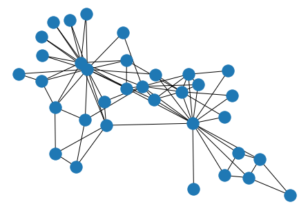

```python
# call the karate club graph
g = nx.karate_club_graph()

# plot the graph
pos = nx.spring_layout(g)
nx.draw(g, pos=pos)

# return the adjacency matrix as a NumPy array
A = nx.to_numpy_array(g)
```

## 3.1 Louvain algorithm for community detection

```python
# use the community Louvain built-in method
partition = community_louvain.best_partition(g)
```

```
indices [0, 1, 2, 3, 4, 5, 6, 7, 8, 9, 10, 11, 12, 13, 14, 15, 16, 17, 18, 19, 20, 21, 22, 23, 24, 25, 26, 27, 28, 29, 30, 31, 32, 33]
partition [0, 0, 0, 0, 1, 1, 1, 0, 2, 2, 1, 0, 0, 0, 2, 2, 1, 0, 2, 0, 2, 0, 2, 2, 3, 3, 2, 2, 3, 2, 2, 3, 2, 2]
```

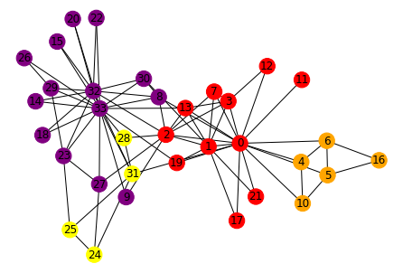

```python
# extract partitions to list from dict
indices = []
partitions = []
for key, value in partition.items():
    indices.append(key)
    partitions.append(value)
print('indices',indices)
print('partition',partitions)

# assign colours to nodes belonging to different partitions
colors_nx = []
for n in partitions:
    if n==0:
        colors_nx.append('red')
    if n==1:
        colors_nx.append('orange')
    if n==2:
        colors_nx.append('purple')
    if n==3:
        colors_nx.append('yellow')

# draw the graph
nx.draw(g, with_labels=True, node_size=300, node_color=colors_nx)
```

#### Compare with 2.3.2 clustering

```
[[32, 33, 8, 14, 15, 18, 20, 22, 23, 24, 25, 26, 27, 28, 29, 30, 31], [1, 2, 3, 7, 9, 12, 13, 17, 21], [0, 4, 5, 6, 10, 11, 16, 19]]
```

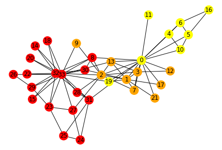

```python
# clustering from 2.3.2
print(clust_232)
nx.draw(g, with_labels=True, node_size=300, node_color=colors)
```

#### Observations:

We see that the cluster that contains the nodes 24, 25, 28 and 31 in the clustering by the Louvain algorithm above is fully contained in the largest clustering produced by the greedy algorithm.

Also, the node 0 with top 2 centrality has switched communities, it is more central now (visually) and the number of nodes in that cluster remains relatively small (it was small in the greedy algorithm case but less central) compared to the cluster that contains 32 and 33.

The higher number of oclusters formed by the Louvain algorithm can be explained by it being a more bottom-up, as it starts by considering each node individually and building up from that, resulting in more clusters at the end, as demonstrated.

Also, node 9 seems to have moved clusters.

#### Differences beetween the CNM (Clauset, Newman and Moore) and Louvain algorithms

Comparing to the greedy algorithm by Clauset, Newman and Moore that produced three nodes, recall that the CNM works by iteratively merging communities that optimize the modularity increase. The Louvain algorithm fixes a problem that arises in a greedy algorithm: the CNM tends to produce lower modularity values than is required, this leads to production of super-communities - a problem that does not scale well to large networks.

The Louvain algorithm considers the gain in modularity by removing an $\textbf{isolated}$ node from its current community and moving it into a neighboring community. This can easily be computed, which significantly increases the algorithm’s efficiency and decreases the susceptibility to the formation of super-communities which was a problem for the CNM greedy algorithm which considered a community as one node in the calculation of modularity.

Sources:

- Vincent D Blondel et al J. Stat. Mech. (2008) P10008, https://iopscience.iop.org/article/10.1088/1742-5468/2008/10/P10008
- "Community detection algorithms: A comparative analysis", Andrea Lancichinetti and Santo Fortunato, Phys. Rev. E 80, 056117 (2009) https://journals.aps.org/pre/abstract/10.1103/PhysRevE.80.056117

## 3.2. Modularity maximisation with spectral partitioning

In this section, we will implement the Louvain algorithm. Its goal: to optimise modularity using a greedy agglomerative algorithm. Modularity is one of the most recent techniques to employ optimisation in graph partitioning. We want to split a graph such that the adjacency matrix with the partitions is as block-diagonal as possible. It is a cost function with two main ingredients:

It is a measure of the relative density of edges inside communities wrt edges outside communities. It is in the range from -1/2 to 1:

$$Q = \frac{1}{2E} \text{Tr} \Big( H^T \big( A - \frac{1}{2E} \textbf{dd}^T \big) H \Big)$$

Pseudocode:

- step 1: optimise (compute) modularity for all nodes locally by moving nodes to the neighboring community that produced in the greatest modularity increase until no modularity increease is found
- step 2: build a new network whose nodes are the communities found during step 1
- step 3: repeat steps 1-2

Sources:

- Vincent D Blondel et al J. Stat. Mech. (2008) P10008, https://iopscience.iop.org/article/10.1088/1742-5468/2008/10/P10008
- "Community detection algorithms: A comparative analysis", Andrea Lancichinetti and Santo Fortunato, Phys. Rev. E 80, 056117 (2009) https://journals.aps.org/pre/abstract/10.1103/PhysRevE.80.056117
- https://web.stanford.edu/class/cs224w/project/26425107.pdf

We first construct the symmetric normalized Laplacian,

$$ \boldsymbol L = \boldsymbol I - \boldsymbol D^{-1/2}\boldsymbol A \boldsymbol D^{-1/2} $$

```python
def get_subgraph(A, nodes):
    """ get the subgraph based on a list of nodes """
    n = len(nodes)
    A_sub = np.zeros((n,n))
    for i in range(n):
        for j in range(i+1,n):
            A_sub[i,j]=A[nodes[i],nodes[j]]
    A_subgraph = A_sub + A_sub.T
    return A_subgraph # return a 2D NumPy array


def get_laplacian(A):
    """ Get Laplacian of my network """
    weighted_degree = A.sum(axis=1)
    # inverse square root vector of degree
    weighted_degree_sqrt = 1.0 / np.sqrt(weighted_degree)
    D_inv_sqrt = np.diag(weighted_degree_sqrt)  # diagonal inv sqrt matrix
    # define the normalised Laplacian
    L_norm = np.eye(A.shape[0]) - D_inv_sqrt.dot(A.dot(D_inv_sqrt))
    return L_norm # return a 2D NumPy array


def get_spectral_partition(A):
    """ Compute spectral partition with Laplacian """
    L = get_laplacian(A)
    eigenvals, eigenvecs = linalg.eigsh(L, 2, which="SM", return_eigenvectors=True)
    # get second eigenvectos because the first one corresponds to 0 eigenvalue
    second_eigenvector = eigenvecs[:,1]
    # define a partition and binarize the negative and positive eigenvector values
    spectral_partition = second_eigenvector
    spectral_partition[spectral_partition<0] = 0
    spectral_partition[spectral_partition>0] = 1
    return spectral_partition # return a 1D NumPy array


def get_modularity(A, partition):
    """ Compute the Modularity of partition with network """
    degree_weighted = A.sum(axis=1)
    m = degree_weighted.sum()/2
    # looping over each pair of nodes
    Q = 0
    for i in range(A.shape[0]):
        for j in range(A.shape[0]):
            # only look at nodes within the same community
            if partition[i]==partition[j]:
                # add the difference between edge and expected edge weight based on degree
                Q += A[i,j] - ((degree_weighted[i]*degree_weighted[j])/(2*m))
    # finally normalise by the total edge weight
    Q = Q/(2*m)
    return Q # return a float


def set_new_partition(possible_partition, sub_partition, idx_nodes, comm_id):
    """ Combine original partition with new subgraph partition """
    sub_partition[sub_partition==0] = comm_id
    sub_partition[sub_partition==1] = comm_id+1
    possible_partition[idx_nodes] = sub_partition
    return possible_partition # return a NumPy array
```

```python
def louvain(A):
    increasing_q = True

    # initial spectral partition
    partition = get_spectral_partition(A)
    Q = get_modularity(A, partition)
    print('Initial Q:', Q)
    comm_id = 0

    # loop over until modularity doesn't increase further
    while increasing_q:

        # define the original modularity
        Q_orig = Q

        # finding unique communities in partition
        unique_comms = np.unique(partition)

        # loop over each community in the partition
        for comm in unique_comms:

            # make a copy of best partition so far
            possible_partition = partition.copy()

            # find index of all nodes in community
            idx_nodes = np.where(partition==comm)[0]

            # get subgraph of graph
            A_sub = get_subgraph(A, idx_nodes)

            # compute spectral partition of subgraph
            sub_partition = get_spectral_partition(A_sub)

            # iterating comm id
            comm_id += 2

            # define new partition
            possible_partition = set_new_partition(possible_partition, sub_partition, idx_nodes, comm_id)

            # compute modularity of new possible partition
            Q_new = get_modularity(A, possible_partition)

            # if the partition of subgraph improved modularity then keep it
            if Q_new>Q:
                partition = possible_partition.copy()
                print('New Q: {}, Partition: {}'.format(Q_new, partition))
                Q = Q_new

        # break out of the while loop if modularity isn't increasing
        if not Q>Q_orig:
            increasing_q = False

    print('------------------')
    print('Optimal number of clusters: {}'.format(np.unique(partition).shape[0]))
    return partition
```

```python
partition_louvain_np = louvain(A)
```

```
Initial Q: 0.35996055226824286
New Q: 0.3744247205785651, Partition: [3. 3. 1. 3. 2. 2. 2. 3. 1. 1. 2. 3. 3. 3. 1. 1. 2. 3. 1. 3. 1. 3. 1. 1.
 1. 1. 1. 1. 1. 1. 1. 1. 1. 1.]
New Q: 0.3892176199868502, Partition: [3. 3. 5. 3. 2. 2. 2. 3. 5. 5. 2. 3. 3. 3. 5. 5. 2. 3. 5. 3. 5. 3. 5. 4.
 4. 4. 5. 4. 4. 5. 5. 4. 5. 5.]
------------------
Optimal number of clusters: 4
```

```python
colors_np = []
for n in partition_louvain_np:
    if n==2:
        colors_np.append('red')
    if n==3:
        colors_np.append('orange')
    if n==4:
        colors_np.append('purple')
    if n==5:
        colors_np.append('yellow')
print('The optimal partition for numpy Louvain is',partition_louvain_np)
```

```
The optimal partition for numpy Louvain is [3. 3. 5. 3. 2. 2. 2. 3. 5. 5. 2. 3. 3. 3. 5. 5. 2. 3. 5. 3. 5. 3. 5. 4.
 4. 4. 5. 4. 4. 5. 5. 4. 5. 5.]
```

Notice that if we merge four clusterings into two, we recover the ground truth with high accuracy:

```python
merge_part = []
for n in partition_louvain_np:
    if n==2:
        merge_part.append(1)
    if n==3:
        merge_part.append(1)
    if n==4:
        merge_part.append(0)
    if n==5:
        merge_part.append(0)
print(np.array(merge_part))
print(ground_truth)

acc1 = np.intersect1d(np.array(merge_part),ground_truth)
print('accuracy',(1-(len(acc1)/len(ground_truth)))*100,'%')

w = np.where(np.array(merge_part)==ground_truth)
print(100*len(w[0])/len(ground_truth),'%')
```

```
[1 1 0 1 1 1 1 1 0 0 1 1 1 1 0 0 1 1 0 1 0 1 0 0 0 0 0 0 0 0 0 0 0 0]
[1 1 1 1 1 1 1 1 1 0 1 1 1 1 0 0 1 1 0 1 0 1 0 0 0 0 0 0 0 0 0 0 0 0]
accuracy 94.11764705882352 %
94.11764705882354 %
```

### 3.2.2 Compare this graph clustering to 2.3.2

We see that this is a slightly different clustering than the one with the built-in method - note members of the second to smallest cluster.

We now have the nodes with top centralities 0 and 33 in different, largest and more central, clusters, which is the most intuitive improvement from 2.3.2, where the node 0 had a much smaller number of nodes in its cluster. The cluster with node 0 now seems to better reflect the high centrality of the node - it has more members.

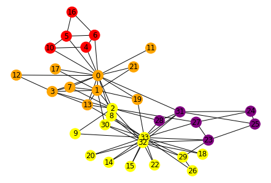

```python
# numpy Louvain graph
nx.draw(g, with_labels=True, node_size=300, node_color=colors_np)
```

```
[[32, 33, 8, 14, 15, 18, 20, 22, 23, 24, 25, 26, 27, 28, 29, 30, 31], [1, 2, 3, 7, 9, 12, 13, 17, 21], [0, 4, 5, 6, 10, 11, 16, 19]]
[2. 1. 1. 1. 2. 2. 2. 1. 0. 1. 2. 2. 1. 1. 0. 0. 2. 1. 0. 2. 0. 1. 0. 0.
 0. 0. 0. 0. 0. 0. 0. 0. 0. 0.]
[1 1 1 1 1 1 1 1 1 0 1 1 1 1 0 0 1 1 0 1 0 1 0 0 0 0 0 0 0 0 0 0 0 0]
[1. 1. 1. 1. 1. 1. 1. 1. 0. 1. 1. 1. 1. 1. 0. 0. 1. 1. 0. 1. 0. 1. 0. 0.
 0. 0. 0. 0. 0. 0. 0. 0. 0. 0.]
[0. 1.]
accuracy 94.11764705882352 %
94.11764705882354 %
Greedy algorithm clustering from 2.3.2
```

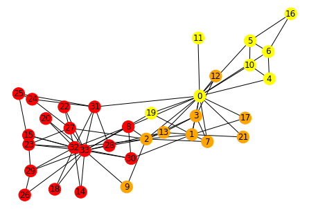

```python
# clustering from 2.3.2
print(clust_232)
nx.draw(g, with_labels=True, node_size=300, node_color=colors)

merge_part_232 = np.zeros(34)
for i in range(3):
    for ind in clust_232[i]:
        merge_part_232[ind]=int(i)
print(merge_part_232)
print(ground_truth)
for i in range(34):
    if merge_part_232[i]==2:
        merge_part_232[i]=1

print(merge_part_232)
a1 = np.intersect1d(merge_part_232,ground_truth)
print(a1)
print('accuracy',(1-(len(a1)/len(ground_truth)))*100,'%')

w1 = np.where(np.array(merge_part_232)==ground_truth)
print(100*len(w1[0])/len(ground_truth),'%')

print('Greedy algorithm clustering from 2.3.2')
```

We see that the accuracy of the clustering is the same when we reduce the number of clusters by merging the smallest ones together. Essentially, it tells us that smaller friendship groups tend to form within the karate clubs, and not between them. From a graph-theoretic point of view, it shows that there are two clearly separable clusters, within which smaller groups can form, but they do not tend cross the two big cluster lines. That is why the more coarse methods such as k-means based on the feature matrix were giving the optimal number of clusters as 2, while these graph-based methods based on the adjacency matrix show the emergence of smaller groups $\textbf{within}$ the two main clusters (karate clubs). This is also because of the nature of the greedy and Louvain modularity-based algorithms that take a bottom-up approach to the community detection in optimising modularity starting from individual nodes, and calculating the modularity for each mini-community (CNM) or individual node (Louvain) merging with/moving to a neighboring community.